# Semantic SEO with Python: classical baseline notebook

This notebook began from a practical search observation: DecrepitFilth.art had started appearing around `semantic seo python` queries. The surrounding search space connected Semantic SEO, Python, NLP, spaCy, BERT, RoBERTa, semantic similarity, keyword clustering, NetworkX, internal linking, content gaps and SEO automation.

This notebook is the response to that opportunity. Rather than treating those terms as article keywords, it implements them as a working Python workflow: search acquisition, page extraction, corpus construction, TF-IDF, c-TF-IDF, NetworkX/Louvain, BERT, RoBERTa, KMeans and HDBSCAN/BERTopic-style clustering.

The code is exposed because implementation choices determine the representation. Each method shows what it finds, what it misses, and what kind of SEO interpretation it can or cannot support.

This is an experiment, not a success narrative. The notebook is also an intervention in the system it measures: a code-heavy public page designed to make the site more useful, more inspectable, and more structurally present in the Semantic SEO Python search space.

The central finding is that the SERP contains the parts of a modern Semantic SEO Python workflow, but not the coherent workflow itself. This notebook occupies that gap by implementing the classical methods, comparing their outputs, and using critique plus human supervision to decide what is actually useful.

# Part A - Classical semantic SEO method permutations

Part A contains the baseline notebook work: the same scraped SERP corpus is passed through the classical Semantic SEO/Python methods identified in the search space. The purpose is to show what TF-IDF, c-TF-IDF, NetworkX/Louvain, BERT, RoBERTa, KMeans and HDBSCAN/BERTopic-style clustering produce when they are asked to represent the same search environment.

This section is intentionally code-heavy. The point is not to claim that any one permutation discovers the true topic structure, but to make each implementation visible enough that its strengths, blind spots and SEO usefulness can be compared.

## 1. Configuration and search keywords

This executed copy replays the frozen corpus by default. Live acquisition can be enabled when a Serper API key is available, but API keys and raw response caches are not included in the public notebook.

```python
# Purpose: Import libraries, define run configuration, and list the target search keywords.

from __future__ import annotations
import os, re, json, math, time, hashlib, warnings, colorsys
from collections import defaultdict
from datetime import datetime, timezone
from pathlib import Path
from urllib.parse import urlparse

warnings.filterwarnings("ignore")

import numpy as np
import pandas as pd
import requests
from bs4 import BeautifulSoup
import matplotlib.pyplot as plt
from matplotlib import cm
from IPython.display import Markdown, display

from sklearn.feature_extraction.text import TfidfVectorizer, CountVectorizer
from sklearn.metrics.pairwise import cosine_similarity
from sklearn.cluster import KMeans
from sklearn.decomposition import TruncatedSVD
from sklearn.preprocessing import normalize
import networkx as nx

try:
    import hdbscan

    HDBSCAN_AVAILABLE = True
except Exception as exc:
    HDBSCAN_AVAILABLE = False
    HDBSCAN_IMPORT_ERROR = repr(exc)
try:
    import umap

    UMAP_AVAILABLE = True
except Exception as exc:
    UMAP_AVAILABLE = False
    UMAP_IMPORT_ERROR = repr(exc)

plt.rcParams["figure.dpi"] = 130
pd.set_option("display.max_colwidth", 110)

PROJECT_ROOT = Path("/root/my-portfolio")
NOTEBOOK_DIR = PROJECT_ROOT / "notebooks"
SNAPSHOT_ROOT = (
    NOTEBOOK_DIR
    / ".local"
    / "semantic-seo-lab"
    / "semantic_seo_python"
    / "20260724T010452Z"
)
SNAPSHOT_ANALYSIS = SNAPSHOT_ROOT / "analysis"
RUN_ID = datetime.now(timezone.utc).strftime("%Y%m%dT%H%M%SZ")
OUTPUT_DIR = NOTEBOOK_DIR / ".local" / "semantic-seo-classical-method-baseline" / RUN_ID
FIG_DIR = OUTPUT_DIR / "figures"
OUTPUT_DIR.mkdir(parents=True, exist_ok=True)
FIG_DIR.mkdir(parents=True, exist_ok=True)
GRAPH_EXPORTS = []
HIERARCHY_EXPORTS = []


def save_graph_png(fig, filename, title, graph_type):
    # Export every graph through one helper so PNG output is auditable.
    path = FIG_DIR / filename
    fig.savefig(path, dpi=180, bbox_inches="tight")
    GRAPH_EXPORTS.append(
        {
            "filename": filename,
            "title": title,
            "graph_type": graph_type,
            "path": str(path),
        }
    )
    return path


RUN_LIVE_ACQUISITION = False
RESULTS_PER_QUERY = 30
REQUEST_TIMEOUT = 20
USER_AGENT = (
    "Mozilla/5.0 (compatible; DecrepitFilthSemanticSeoLab/1.0; "
    "+https://decrepitfilth.art/)"
)

SEARCH_KEYWORDS = [
    "seo automation python",
    "networkx seo",
    "bert semantic seo",
    "semantic keyword clustering python",
    "nlp for seo",
    "spacy seo",
    "python for seo",
    "semantic seo nlp",
    "roberta semantic similarity seo",
    "semantic seo python",
    "python internal linking seo",
    "python content gap analysis",
]

print("run_id:", RUN_ID)
print("keywords:", len(SEARCH_KEYWORDS))
print("private output:", OUTPUT_DIR)
```

```
run_id: 20260727T230109Z
keywords: 12
private output: /root/my-portfolio/notebooks/.local/semantic-seo-classical-method-baseline/20260727T230109Z
```

## 2. Acquisition code: Serper, Requests and BeautifulSoup

This code is included because the page is also about SEO automation with Python. The notebook can run live, but this rendered execution uses the existing frozen snapshot.

```python
# Purpose: Define live SERP acquisition and page extraction helpers without storing API keys.


def stable_id(value, prefix="page"):
    return (
        f"{prefix}_"
        + hashlib.sha256(str(value).encode("utf-8", errors="ignore")).hexdigest()[:16]
    )


def normalise_url(url):
    url = str(url or "").strip()
    if not url:
        return ""
    p = urlparse(url)
    return f'{p.scheme or "https"}://{p.netloc.lower()}{(p.path.rstrip("/") or "/")}'


def domain_from_url(url):
    return urlparse(str(url)).netloc.lower().replace("www.", "")


def serper_search(query, api_key, num=30):
    r = requests.post(
        "https://google.serper.dev/search",
        headers={"X-API-KEY": api_key, "Content-Type": "application/json"},
        json={"q": query, "num": num},
        timeout=REQUEST_TIMEOUT,
    )
    r.raise_for_status()
    rows = []
    for i, item in enumerate(r.json().get("organic", []), start=1):
        url = normalise_url(item.get("link") or item.get("url") or "")
        rows.append(
            {
                "query": query,
                "rank": i,
                "candidate_url": url,
                "serp_title": item.get("title", ""),
                "serp_snippet": item.get("snippet", ""),
                "page_id": stable_id(url),
            }
        )
    return rows


def extract_page(url):
    try:
        r = requests.get(
            url,
            headers={"User-Agent": USER_AGENT},
            timeout=REQUEST_TIMEOUT,
            allow_redirects=True,
        )
        html = r.text if r.ok else ""
    except Exception as exc:
        return {
            "candidate_url": url,
            "final_fetch_url": url,
            "page_id": stable_id(url),
            "fetch_status": "error",
            "error": repr(exc),
            "title": "",
            "meta_description": "",
            "h1": "",
            "headings": [],
            "clean_body": "",
        }
    soup = BeautifulSoup(html, "html.parser")
    for tag in soup(["script", "style", "noscript", "svg", "iframe"]):
        tag.decompose()
    meta = soup.find("meta", attrs={"name": re.compile("description", re.I)})
    return {
        "candidate_url": url,
        "final_fetch_url": r.url,
        "page_id": stable_id(normalise_url(url)),
        "fetch_status": "success" if html else "failed",
        "http_status": r.status_code,
        "title": soup.title.get_text(" ", strip=True) if soup.title else "",
        "meta_description": meta.get("content", "").strip() if meta else "",
        "h1": soup.find("h1").get_text(" ", strip=True) if soup.find("h1") else "",
        "headings": [
            h.get_text(" ", strip=True) for h in soup.find_all(re.compile("^h[1-3]$"))
        ][:40],
        "clean_body": re.sub(r"\s+", " ", soup.get_text(" ", strip=True))[:50000],
    }


def run_live_acquisition():
    api_key = os.getenv("SERPER_API_KEY")
    if not api_key:
        raise RuntimeError("SERPER_API_KEY is required for live acquisition.")
    hits = []
    for q in SEARCH_KEYWORDS:
        hits.extend(serper_search(q, api_key, RESULTS_PER_QUERY))
        time.sleep(0.2)
    hits = pd.DataFrame(hits).drop_duplicates(["query", "candidate_url"])
    pages = [extract_page(u) for u in sorted(hits.candidate_url.dropna().unique())]
    return hits, pd.DataFrame(pages)


print("acquisition functions ready")
```

```
acquisition functions ready
```

## 3. Load or acquire corpus

The analysis uses one document per successfully extracted page. SERP query/rank data is retained as provenance.

```python
# Purpose: Load the frozen corpus or run live acquisition, then assemble page-level analysis text.


def load_snapshot(root):
    hits = pd.read_csv(root / "query_hits.csv")
    rows = [
        json.loads(line)
        for line in (root / "pages_extracted.jsonl")
        .read_text(encoding="utf-8")
        .splitlines()
        if line.strip()
    ]
    return hits, pd.DataFrame(rows)


if RUN_LIVE_ACQUISITION:
    query_hits, pages_raw = run_live_acquisition()
    source = "live acquisition"
else:
    query_hits, pages_raw = load_snapshot(SNAPSHOT_ROOT)
    source = str(SNAPSHOT_ROOT)

pages = pages_raw.copy()
if "fetch_status" in pages.columns:
    pages = pages[pages.fetch_status.astype(str).eq("success")].copy()
for col in ["title", "meta_description", "h1", "clean_body"]:
    pages[col] = pages.get(col, "").fillna("").astype(str)
pages["headings"] = pages.get("headings", [[] for _ in range(len(pages))])
pages["url"] = (
    pages.get("resolved_identity_url", pages.get("candidate_url", ""))
    .fillna("")
    .astype(str)
)
pages["domain"] = pages.url.map(domain_from_url)


def normalise_heading_text(value):
    if isinstance(value, list):
        parts = []
        for item in value:
            if isinstance(item, dict):
                parts.append(
                    str(
                        item.get("text")
                        or item.get("heading")
                        or item.get("label")
                        or " ".join(map(str, item.values()))
                    )
                )
            else:
                parts.append(str(item))
        return " ".join(parts)
    if isinstance(value, dict):
        return str(
            value.get("text")
            or value.get("heading")
            or value.get("label")
            or " ".join(map(str, value.values()))
        )
    return str(value)


pages["heading_text"] = pages.headings.apply(normalise_heading_text)
pages["document_text"] = (
    pages.title
    + ". "
    + pages.meta_description
    + ". "
    + pages.h1
    + ". "
    + pages.heading_text
    + ". "
    + pages.clean_body.str.slice(0, 6000)
)
pages = pages.drop_duplicates("page_id").reset_index(drop=True)
query_map = (
    query_hits.groupby("page_id")["query"]
    .apply(lambda s: " | ".join(sorted(set(map(str, s)))))
    .to_dict()
)
rank_map = (
    pd.to_numeric(query_hits["rank"], errors="coerce")
    .groupby(query_hits.page_id)
    .min()
    .to_dict()
)
pages["queries"] = pages.page_id.map(query_map).fillna("")
pages["best_rank"] = pages.page_id.map(rank_map)
summary = {
    "source": source,
    "queries": len(SEARCH_KEYWORDS),
    "serp_hits": len(query_hits),
    "unique_serp_pages": query_hits.page_id.nunique(),
    "extracted_pages": len(pages),
    "domains": pages.domain.nunique(),
}
display(
    Markdown(
        f"**Corpus loaded:** {summary['extracted_pages']} extracted pages "
        f"from {summary['domains']} domains, collected from "
        f"{summary['queries']} Semantic SEO/Python search queries."
    )
)
```

**Corpus loaded:** 169 extracted pages from 133 domains, collected from 12 Semantic SEO/Python search queries.

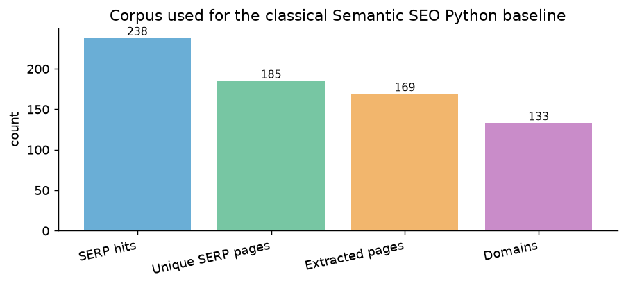

*The acquisition chart establishes the scale of the evidence base before any topic model is interpreted. The scrape rate and domain count are part of the SEO evidence, not background trivia.*

```python
# Purpose: Visualise the acquisition summary so the sample size is inspectable at a glance.

fig, ax = plt.subplots(figsize=(8, 3.3))
labels = ["SERP hits", "Unique SERP pages", "Extracted pages", "Domains"]
vals = [
    summary["serp_hits"],
    summary["unique_serp_pages"],
    summary["extracted_pages"],
    summary["domains"],
]
ax.bar(labels, vals, color=["#6aaed6", "#77c6a3", "#f2b66d", "#c98cc9"])
for i, v in enumerate(vals):
    ax.text(i, v, str(v), ha="center", va="bottom", fontsize=9)
ax.set_title("Corpus used for the classical Semantic SEO Python baseline")
ax.set_ylabel("count")
ax.spines[["top", "right"]].set_visible(False)
fig.autofmt_xdate(rotation=12)
save_graph_png(
    fig, "01_acquisition_summary.png", ax.get_title(), "acquisition_bar_chart"
)
plt.show()
display(
    Markdown(
        "*The acquisition chart establishes the scale of the evidence base before "
        "any topic model is interpreted. The scrape rate and domain count are "
        "part of the SEO evidence, not background trivia.*"
    )
)
```

## 4. Shared preprocessing and visual helpers

All permutations use the same page corpus. The methods change, not the input data.

```python
# Purpose: Create shared text preprocessing, labelling, graph, clustering, and plotting helpers.

STOPWORDS = set("""
    about above after again against all also am an and any are as at be because
    been before being below between both but by can could did do does doing down
    during each few for from further had has have having he her here hers herself
    him himself his how i if in into is it its itself just me more most my myself
    no nor not now of off on once only or other our ours ourselves out over own
    same she should so some such than that the their theirs them themselves then
    there these they this those through to too under until up very was we were
    what when where which while who whom why will with you your yours yourself
    yourselves
    """.split())
DOMAIN_STOPWORDS = STOPWORDS | set("""
    seo search google page pages website websites content blog post guide learn
    use using used users user data tools tool free best online example examples
    need make makes like get one two way ways work works working click read
    article articles step steps help helps service services business digital
    marketing agency expert company home contact privacy terms cookies report
    reports
    """.split())


def clean_text(text):
    text = str(text).lower()
    text = re.sub(r"https?://\S+", " ", text)
    text = re.sub(r"[^a-z0-9\s\-]", " ", text)
    return re.sub(r"\s+", " ", text).strip()


pages["clean_for_model"] = pages.document_text.map(clean_text)
vectorizer = TfidfVectorizer(
    stop_words=sorted(DOMAIN_STOPWORDS),
    ngram_range=(1, 3),
    min_df=2,
    max_df=0.72,
    max_features=4500,
)
X = vectorizer.fit_transform(pages.clean_for_model)
terms = np.array(vectorizer.get_feature_names_out())
print("TF-IDF matrix:", X.shape)


def top_terms(indices, matrix=X, feature_names=terms, n=10):
    if len(indices) == 0:
        return []
    scores = np.asarray(matrix[indices].mean(axis=0)).ravel()
    order = scores.argsort()[::-1]
    return [feature_names[i] for i in order[:n] if scores[i] > 0]


def ctfidf_labels(labels, docs, n=10):
    labels = np.asarray(labels)
    groups = []
    ids = []
    for cid in sorted(set(labels)):
        if cid == -1:
            continue
        idx = np.where(labels == cid)[0]
        ids.append(int(cid))
        groups.append(" ".join(docs[i] for i in idx))
    if not groups:
        return {}
    cv = CountVectorizer(
        stop_words=sorted(DOMAIN_STOPWORDS),
        ngram_range=(1, 3),
        min_df=1,
        max_features=4000,
    )
    counts = cv.fit_transform(groups).astype(float)
    vocab = np.array(cv.get_feature_names_out())
    tf = counts.multiply(1 / np.maximum(counts.sum(axis=1), 1))
    df = np.asarray((counts > 0).sum(axis=0)).ravel()
    scores = tf.multiply(np.log(1 + len(groups) / np.maximum(df, 1))).tocsr()
    out = {}
    for r, cid in enumerate(ids):
        arr = np.asarray(scores[r].todense()).ravel()
        order = arr.argsort()[::-1]
        out[cid] = [vocab[i] for i in order[:n] if arr[i] > 0]
    return out


def page_graph(matrix, top_k=7, min_sim=0.11):
    sim = cosine_similarity(matrix)
    G = nx.Graph()
    for i, row in pages.iterrows():
        G.add_node(i, label=row.title[:90], domain=row.domain)
    for i in range(sim.shape[0]):
        for j in np.argsort(sim[i])[::-1][1 : top_k + 1]:
            if j > i and sim[i, j] >= min_sim:
                G.add_edge(i, j, weight=float(sim[i, j]))
    return G


def louvain(G):
    if G.number_of_edges() == 0:
        return np.zeros(G.number_of_nodes(), dtype=int)
    labels = np.full(G.number_of_nodes(), -1, dtype=int)
    communities = nx.algorithms.community.louvain_communities(
        G,
        weight="weight",
        seed=42,
    )
    for cid, members in enumerate(communities):
        for m in members:
            labels[m] = cid
    return labels


def summarize(labels, label_terms, method):
    rows = []
    labels = np.asarray(labels)
    for cid in sorted(set(labels)):
        idx = np.where(labels == cid)[0]
        if cid != -1:
            terms_s = " | ".join(label_terms.get(int(cid), top_terms(idx, n=8))[:8])
        else:
            terms_s = "noise / unassigned"
        if len(idx):
            reps = " || ".join(
                pages.iloc[idx]
                .sort_values("best_rank", na_position="last")
                .title.head(3)
                .tolist()
            )
        else:
            reps = ""
        rows.append(
            {
                "method": method,
                "cluster_id": int(cid),
                "page_count": len(idx),
                "domain_count": pages.iloc[idx].domain.nunique() if len(idx) else 0,
                "label_terms": terms_s,
                "representative_pages": reps,
            }
        )
    return pd.DataFrame(rows).sort_values(
        ["page_count", "domain_count"], ascending=False
    )


def split_label_terms(value, max_terms=None):
    terms_out = [term.strip() for term in str(value).split("|") if term.strip()]
    return terms_out[:max_terms] if max_terms else terms_out


def topic_candidate_name(terms):
    # Heuristic labels make the hierarchy scannable without claiming taxonomy.
    text = " ".join(terms).lower()
    rules = [
        ("Python SEO automation and scripting", ["python", "automation"]),
        ("Semantic search, entities, and intent", ["semantic", "entities"]),
        ("BERT / embedding similarity", ["bert", "similarity"]),
        ("Semantic keyword clustering", ["keyword", "clustering"]),
        ("spaCy / NLP implementation", ["spacy"]),
        ("Content gap and competitor analysis", ["gap", "competitor"]),
        ("Internal linking and site graph repair", ["internal", "link"]),
        ("NetworkX graph modelling", ["networkx", "graph"]),
        ("Natural language processing for SEO", ["natural language", "nlp"]),
        ("Machine learning for SEO analysis", ["machine learning"]),
    ]
    for label, required in rules:
        if all(part in text for part in required):
            return label
    return " / ".join(terms[:3]) if terms else "Unlabelled topic candidate"
```

```python
def hierarchy_rows(summary_df, method, max_clusters=14, terms_per_cluster=8):
    rows = []
    usable = summary_df[summary_df.cluster_id != -1].head(max_clusters)
    for _, row in usable.iterrows():
        terms_for_cluster = split_label_terms(row.label_terms, terms_per_cluster)
        reps = [
            title.strip()
            for title in str(row.representative_pages).split("||")
            if title.strip()
        ][:3]
        rows.append(
            {
                "method": method,
                "cluster_id": f"C{int(row.cluster_id)}",
                "topic_candidate": topic_candidate_name(terms_for_cluster),
                "page_count": int(row.page_count),
                "domain_count": int(row.domain_count),
                "label_terms": " | ".join(terms_for_cluster),
                "representative_pages": " || ".join(reps),
            }
        )
    return pd.DataFrame(rows)


def hierarchy_markdown(hierarchy_df, method, limitation):
    lines = [
        f"### Provisional hierarchy: {method}",
        "",
        (
            "This is not a proven taxonomy. It is the hierarchy implied by this "
            "method: detected cluster -> candidate topic -> label-term evidence "
            "-> representative pages."
        ),
        "",
    ]
    for _, row in hierarchy_df.iterrows():
        terms_for_cluster = split_label_terms(row.label_terms, 8)
        reps = [
            page.strip()
            for page in str(row.representative_pages).split("||")
            if page.strip()
        ][:2]
        lines.extend(
            [
                (
                    f"- **{row.cluster_id}: {row.topic_candidate}** "
                    f"({row.page_count} pages / {row.domain_count} domains)"
                ),
                f"  - Label evidence: {', '.join(terms_for_cluster)}",
            ]
        )
        if reps:
            lines.append(f"  - Representative pages: {'; '.join(reps)}")
    lines.extend(["", f"**Method caution:** {limitation}"])
    return "\n".join(lines)


def display_topic_hierarchy(summary_df, method, limitation, filename_stub=None):
    # Display the review hierarchy without exporting per-method markdown/CSV files.
    hierarchy_df = hierarchy_rows(summary_df, method)
    markdown_text = hierarchy_markdown(hierarchy_df, method, limitation)
    display(Markdown(markdown_text))
    return hierarchy_df


METHOD_HEALTH_RECORDS = []


def method_health(labels, method):
    labels = np.asarray(labels)
    total = max(len(labels), 1)
    counts = pd.Series(labels).value_counts().sort_index()
    cluster_counts = counts[counts.index != -1]
    cluster_count = int(len(cluster_counts))
    largest_cluster_share = (
        float(cluster_counts.max() / total) if cluster_count else 0.0
    )
    noise_share = float(counts.get(-1, 0) / total)

    if largest_cluster_share > 0.50:
        method_status = "over-compressed"
    elif cluster_count < 2:
        method_status = "too few clusters"
    elif noise_share > 0.40:
        method_status = "noise-heavy"
    else:
        method_status = "usable baseline"

    return {
        "method": method,
        "cluster_count": cluster_count,
        "largest_cluster_share": round(largest_cluster_share, 3),
        "noise_share": round(noise_share, 3),
        "method_status": method_status,
    }


def register_method_health(labels, method):
    health = method_health(labels, method)
    METHOD_HEALTH_RECORDS.append(health)
    return health


def seo_interpretation_from_terms(terms):
    text = " ".join(terms).lower()
    if "internal" in text and "link" in text:
        return "Internal linking and site-graph intervention."
    if "gap" in text or "competitor" in text:
        return "Content-gap or competitor-analysis workflow."
    if "networkx" in text or "graph" in text or "edge" in text:
        return "Graph representation and relationship modelling."
    if "bert" in text or "roberta" in text or "embedding" in text:
        return "Transformer similarity / semantic representation."
    if "spacy" in text or "nlp" in text or "language" in text:
        return "NLP extraction and language-processing implementation."
    if "cluster" in text or "keyword" in text:
        return "Keyword clustering and topic grouping."
    if "automation" in text or "script" in text or "python" in text:
        return "Python SEO automation and scripting."
    return "Candidate SEO topic; requires human review."


def public_cluster_table(summary_df, max_rows=8):
    rows = []
    usable = summary_df[summary_df.cluster_id != -1].head(max_rows)
    for _, row in usable.iterrows():
        terms_for_cluster = split_label_terms(row.label_terms, 8)
        rows.append(
            {
                "method": row.method,
                "cluster_id": f"C{int(row.cluster_id)}",
                "page_count": int(row.page_count),
                "label_terms": " | ".join(terms_for_cluster),
                "SEO interpretation": seo_interpretation_from_terms(terms_for_cluster),
            }
        )
    return pd.DataFrame(rows)


def display_method_health_and_table(summary_df, labels, method, max_rows=8):
    health = register_method_health(labels, method)
    status = health["method_status"]
    display(
        Markdown(
            f"**Method health:** {health['cluster_count']} clusters; "
            f"largest cluster share {health['largest_cluster_share']:.1%}; "
            f"noise share {health['noise_share']:.1%}; status: **{status}**."
        )
    )
    table = public_cluster_table(summary_df, max_rows=max_rows)
    display(table)
    return health, table


def figure_caption(text):
    display(Markdown(f"*{text}*"))


def cluster_palette(labels):
    # Stable colours for detected communities or vector-space clusters.
    ids = sorted(set(int(x) for x in labels if int(x) != -1))
    cmap = plt.get_cmap("tab20", max(len(ids), 1))
    colours = {cid: cmap(index) for index, cid in enumerate(ids)}
    colours[-1] = (0.72, 0.72, 0.72, 0.55)
    return colours
```

```python
def short_terms(value, n=4):
    return [term.strip() for term in str(value).split("|") if term.strip()][:n]


def cluster_label_map(summary_df, n=3):
    labels = {}
    for _, row in summary_df[summary_df.cluster_id != -1].iterrows():
        terms_for_cluster = short_terms(row.label_terms, n)
        label = f"C{int(row.cluster_id)}: " + ", ".join(terms_for_cluster)
        labels[int(row.cluster_id)] = label[:72]
    return labels


def plot_louvain_page_network(G, labels, summary_df, title, filename):
    # Louvain is genuinely graph-based, so show the page-similarity graph.
    # Node colour = detected community; centroid label = cluster label terms.
    labels = np.asarray(labels)
    colours = cluster_palette(labels)
    pos = nx.spring_layout(G, seed=42, weight="weight", k=0.42, iterations=140)
    fig, ax = plt.subplots(figsize=(13.5, 9.2))
    ax.set_facecolor("#fbfbfb")

    edge_widths = [max(0.25, G.edges[e].get("weight", 0.1) * 2.2) for e in G.edges]
    nx.draw_networkx_edges(
        G,
        pos,
        ax=ax,
        edge_color="#94a3b8",
        width=edge_widths,
        alpha=0.20,
    )

    node_colours = [colours.get(int(labels[node]), colours[-1]) for node in G.nodes]
    node_sizes = [34 if int(labels[node]) != -1 else 16 for node in G.nodes]
    nx.draw_networkx_nodes(
        G,
        pos,
        node_size=node_sizes,
        node_color=node_colours,
        edgecolors="white",
        linewidths=0.35,
        ax=ax,
    )

    label_terms = cluster_label_map(summary_df)
    for cid, label in label_terms.items():
        idx = [node for node in G.nodes if int(labels[node]) == cid]
        if not idx:
            continue
        xs = [pos[node][0] for node in idx]
        ys = [pos[node][1] for node in idx]
        ax.text(
            float(np.mean(xs)),
            float(np.mean(ys)),
            label,
            ha="center",
            va="center",
            fontsize=8,
            color="#111827",
            bbox=dict(
                boxstyle="round,pad=.25",
                facecolor="white",
                alpha=0.86,
                edgecolor="none",
            ),
        )

    ax.set_title(title)
    ax.axis("off")
    fig.tight_layout()
    save_graph_png(fig, filename, title, "louvain_page_graph")
    plt.show()


def plot_topic_cards(summary_df, title, filename, max_clusters=10, terms_per_cluster=6):
    # KMeans/HDBSCAN do not produce relation networks.
    # Topic cards make their cluster labels and evidence reviewable instead.
    import textwrap

    df = (
        summary_df[summary_df.cluster_id != -1]
        .head(max_clusters)
        .reset_index(drop=True)
    )
    columns = 2
    rows = math.ceil(max(len(df), 1) / columns)
    fig_height = max(4.2, rows * 3.25)
    fig, axes = plt.subplots(rows, columns, figsize=(14.5, fig_height))
    axes = np.atleast_1d(axes).ravel()
    cmap = plt.get_cmap("tab20", max(len(df), 1))

    for ax in axes:
        ax.axis("off")

    for index, (_, row) in enumerate(df.iterrows()):
        ax = axes[index]
        colour = cmap(index)
        terms_for_cluster = short_terms(row.label_terms, terms_per_cluster)
        term_line = ", ".join(terms_for_cluster)
        term_text = textwrap.fill(term_line, width=58)
        reps = [
            page.strip()
            for page in str(row.representative_pages).split("||")
            if page.strip()
        ][:2]
        evidence_lines = []
        for rep in reps:
            wrapped = textwrap.wrap(rep, width=62)
            if wrapped:
                evidence_lines.append(f"- {wrapped[0]}")
                evidence_lines.extend(f"  {line}" for line in wrapped[1:2])
        title_text = f"C{int(row.cluster_id)} · {int(row.page_count)} pages"
        body = "\n".join(
            [
                term_text,
                "",
                "Evidence:",
                *(evidence_lines if evidence_lines else ["- no representative page"]),
            ]
        )
        ax.add_patch(
            plt.Rectangle(
                (0, 0),
                1,
                1,
                transform=ax.transAxes,
                facecolor=(colour[0], colour[1], colour[2], 0.14),
                edgecolor=colour,
                linewidth=1.6,
            )
        )
        ax.text(
            0.045,
            0.89,
            title_text,
            transform=ax.transAxes,
            ha="left",
            va="top",
            fontsize=12,
            fontweight="bold",
            color="#111827",
        )
        ax.text(
            0.045,
            0.73,
            body,
            transform=ax.transAxes,
            ha="left",
            va="top",
            fontsize=10.2,
            color="#111827",
            linespacing=1.32,
        )

    fig.suptitle(title, y=0.995, fontsize=14)
    fig.tight_layout(rect=(0, 0, 1, 0.965), h_pad=0.9, w_pad=0.7)
    save_graph_png(fig, filename, title, "topic_cards")
    plt.show()


def plot_scatter(emb, labels, summary_df, title, filename):
    # Embedding methods produce point clouds, not relation networks.
    # This plot shows where each page sits in a reduced embedding space.
    emb = np.asarray(emb)
    if emb.shape[1] > 2:
        coords = TruncatedSVD(n_components=2, random_state=42).fit_transform(
            normalize(emb)
        )
    else:
        coords = emb

    labels = np.asarray(labels)
    fig, ax = plt.subplots(figsize=(10.5, 7))
    cmap = plt.get_cmap("tab20", max(len(set(labels)), 1))

    for n, cid in enumerate(sorted(set(labels))):
        mask = labels == cid
        ax.scatter(
            coords[mask, 0],
            coords[mask, 1],
            s=38,
            alpha=0.75,
            label=f"C{cid}",
            color=cmap(n),
        )

    labelled = summary_df[summary_df.cluster_id != -1].head(10)
    for _, row in labelled.iterrows():
        idx = np.where(labels == row.cluster_id)[0]
        if len(idx):
            x, y = coords[idx].mean(axis=0)
            terms = ", ".join(str(row.label_terms).split("|")[:3])
            label = f"C{int(row.cluster_id)}: {terms}"
            ax.text(
                x,
                y,
                label[:75],
                fontsize=7.5,
                ha="center",
                va="center",
                bbox=dict(
                    boxstyle="round,pad=.25",
                    facecolor="white",
                    alpha=0.72,
                    edgecolor="none",
                ),
            )
```

```python
    ax.set_title(title)
    ax.spines[["top", "right"]].set_visible(False)
    save_graph_png(fig, filename, title, "embedding_scatter")
    plt.show()
```

```
TF-IDF matrix: (169, 4500)
```

## 5. NetworkX-Louvain x TF-IDF

Graph-first baseline: TF-IDF page similarity becomes a NetworkX graph; Louvain detects communities; TF-IDF labels them.

```
page graph: 169 nodes, 528 edges
```

**Method health:** 14 clusters; largest cluster share 18.3%; noise share 0.0%; status: **usable baseline**.

|  | method | cluster_id | page_count | label_terms | SEO interpretation |
| --- | --- | --- | --- | --- | --- |
| 0 | NetworkX-Louvain x TF-IDF | C0 | 31 | python \| automation \| tasks \| scripts \| automate \| analysis \| script \| keyword | Keyword clustering and topic grouping. |
| 1 | NetworkX-Louvain x TF-IDF | C11 | 26 | semantic \| ai \| engines \| entities \| nlp \| intent \| keywords \| entity | NLP extraction and language-processing implementation. |
| 2 | NetworkX-Louvain x TF-IDF | C9 | 18 | bert \| sentence \| similarity \| semantic \| model \| embeddings \| models \| sbert | Transformer similarity / semantic representation. |
| 3 | NetworkX-Louvain x TF-IDF | C7 | 18 | clustering \| keyword \| keyword clustering \| semantic \| keywords \| semantic keyword \| cluster \| grouping | Keyword clustering and topic grouping. |
| 4 | NetworkX-Louvain x TF-IDF | C5 | 17 | spacy \| nlp \| python \| text \| semantic \| python nlp \| nltk \| en | NLP extraction and language-processing implementation. |
| 5 | NetworkX-Louvain x TF-IDF | C1 | 16 | gap \| gap analysis \| analysis \| gaps \| competitors \| ai \| keywords \| competitor | Content-gap or competitor-analysis workflow. |
| 6 | NetworkX-Louvain x TF-IDF | C12 | 15 | nlp \| language \| natural \| natural language \| natural language processing \| language processing \| processi... | NLP extraction and language-processing implementation. |
| 7 | NetworkX-Louvain x TF-IDF | C4 | 12 | internal \| links \| linking \| internal linking \| internal links \| link \| site \| internal linking strategy | Internal linking and site-graph intervention. |

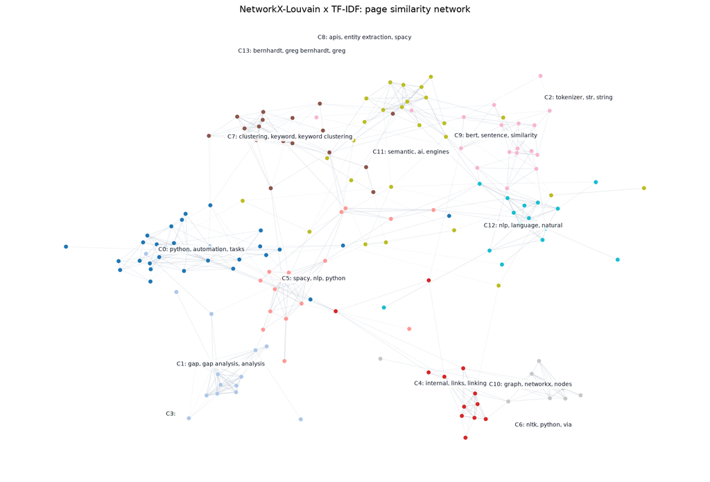

*This is the one retained Louvain network visual. It shows the page-similarity graph that Louvain actually partitions; the labels are review aids, not proven topic names.*

Provisional hierarchy: NetworkX-Louvain x TF-IDF

This is not a proven taxonomy. It is the hierarchy implied by this method: detected cluster -> candidate topic -> label-term evidence -> representative pages.

- **C0: Python SEO automation and scripting** (31 pages / 27 domains)

  - Label evidence: python, automation, tasks, scripts, automate, analysis, script, keyword

  - Representative pages: Python for SEO & Content Marketing; Python for SEO, Explained for Beginners

- **C11: Semantic search, entities, and intent** (26 pages / 25 domains)

  - Label evidence: semantic, ai, engines, entities, nlp, intent, keywords, entity

  - Representative pages: Semantic Search Explained: Vector Models' Impact on SEO Today - Lumar; Semantic SEO: Mastering Modern Search Optimization

- **C9: BERT / embedding similarity** (18 pages / 18 domains)

  - Label evidence: bert, sentence, similarity, semantic, model, embeddings, models, sbert

  - Representative pages: BERT and NLP: Revolutionizing SEO Strategies for Top Search Rankings | SEO 101; RoBERTa Semantic Embeddings Overview

- **C7: Semantic keyword clustering** (18 pages / 16 domains)

  - Label evidence: clustering, keyword, keyword clustering, semantic, keywords, semantic keyword, cluster, grouping

  - Representative pages: Semantic Keyword Clustering in Python; Semantic Keyword Clustering For 10,000+ Keywords [With Script]

- **C5: spaCy / NLP implementation** (17 pages / 11 domains)

  - Label evidence: spacy, nlp, python, text, semantic, python nlp, nltk, en

  - Representative pages: Medium; spaCy · Industrial-strength Natural Language Processing in Python

- **C1: Content gap and competitor analysis** (16 pages / 16 domains)

  - Label evidence: gap, gap analysis, analysis, gaps, competitors, ai, keywords, competitor

  - Representative pages: Content gap analysis: A step-by-step guide; Run a Content Gap Analysis to Create Content People Crave

- **C12: Natural language processing for SEO** (15 pages / 15 domains)

  - Label evidence: nlp, language, natural, natural language, natural language processing, language processing, processing, intent

  - Representative pages: NLP in SEO: What It Is & How to Use It to Optimize Your Content; NLP in SEO: How to Optimize Your Site for Search Intent

- **C4: Internal linking and site graph repair** (12 pages / 12 domains)

  - Label evidence: internal, links, linking, internal linking, internal links, link, site, internal linking strategy

  - Representative pages: Find Internal linking opportunities with Python for SEO - Daniel Heredia; Building an internal linking recommender using Python, SERP API, and semantic similarity

- **C10: NetworkX graph modelling** (11 pages / 7 domains)

  - Label evidence: graph, networkx, nodes, edges, node, graphs, edge, nx

  - Representative pages: Tutorial — NetworkX 3.6.1 documentation; Introduction — NetworkX 3.6.1 documentation

- **C2: tokenizer / str / string** (1 pages / 1 domains)

  - Label evidence: tokenizer, str, string, method, optional, returns, name description, segment

  - Representative pages: Tokenizer · spaCy API Documentation

- **C3: Unlabelled topic candidate** (1 pages / 1 domains)

  - Label evidence:

- **C6: nltk / python / via** (1 pages / 1 domains)

  - Label evidence: nltk, python, via, berk, tu, tu berk, koray tu berk, koray

  - Representative pages: Python SEO Category Guidelines, Tips and Lectures - Holistic SEO

- **C8: spaCy / NLP implementation** (1 pages / 1 domains)

  - Label evidence: apis, entity extraction, spacy, api, source nlp, generative ai, nlp, extraction

  - Representative pages: spaCy - MLforSEO

- **C13: bernhardt / greg bernhardt / greg** (1 pages / 1 domains)

  - Label evidence: bernhardt, greg bernhardt, greg, python, 03, bulk, 500, 02

  - Representative pages: ImportSEM - Advanced Python SEO

**Method caution:** Broad discovery map, but weak co-occurrence can be mistaken for structure.

```python
# Purpose: Build the TF-IDF similarity graph and label Louvain communities with TF-IDF terms.

G = page_graph(X)
labels_louvain = louvain(G)
terms_louvain_tfidf = {
    int(c): top_terms(np.where(labels_louvain == c)[0], n=10)
    for c in sorted(set(labels_louvain))
    if c != -1
}
summary_louvain_tfidf = summarize(
    labels_louvain,
    terms_louvain_tfidf,
    "NetworkX-Louvain x TF-IDF",
)
print("page graph:", G.number_of_nodes(), "nodes,", G.number_of_edges(), "edges")
health_louvain_tfidf, public_louvain_tfidf = display_method_health_and_table(
    summary_louvain_tfidf,
    labels_louvain,
    "NetworkX-Louvain x TF-IDF",
)
plot_louvain_page_network(
    G,
    labels_louvain,
    summary_louvain_tfidf,
    "NetworkX-Louvain x TF-IDF: page similarity network",
    "02_louvain_tfidf_page_network.png",
)
figure_caption(
    "This is the one retained Louvain network visual. It shows the page-similarity graph "
    "that Louvain actually partitions; the labels are review aids, not proven topic names."
)
hierarchy_louvain_tfidf = display_topic_hierarchy(
    summary_louvain_tfidf,
    "NetworkX-Louvain x TF-IDF",
    "Broad discovery map, but weak co-occurrence can be mistaken for structure.",
)
```

## 6. NetworkX-Louvain x c-TF-IDF

Same Louvain communities, different labels. c-TF-IDF highlights terms distinctive to each community.

```python
# Purpose: Reuse the Louvain communities and relabel them with c-TF-IDF distinctive terms.

terms_louvain_ctfidf = ctfidf_labels(
    labels_louvain,
    pages.clean_for_model.tolist(),
    n=10,
)
summary_louvain_ctfidf = summarize(
    labels_louvain,
    terms_louvain_ctfidf,
    "NetworkX-Louvain x c-TF-IDF",
)
health_louvain_ctfidf, public_louvain_ctfidf = display_method_health_and_table(
    summary_louvain_ctfidf,
    labels_louvain,
    "NetworkX-Louvain x c-TF-IDF",
)
display(
    Markdown(
        "*This variant reuses the Louvain partition above. The graph is not repeated; "
        "only the community labels change from TF-IDF to c-TF-IDF.*"
    )
)
hierarchy_louvain_ctfidf = display_topic_hierarchy(
    summary_louvain_ctfidf,
    "NetworkX-Louvain x c-TF-IDF",
    "c-TF-IDF sharpens labels, but it does not validate the Louvain partition.",
)
```

**Method health:** 14 clusters; largest cluster share 18.3%; noise share 0.0%; status: **usable baseline**.

|  | method | cluster_id | page_count | label_terms | SEO interpretation |
| --- | --- | --- | --- | --- | --- |
| 0 | NetworkX-Louvain x c-TF-IDF | C0 | 31 | python \| automation \| tasks \| scripts \| lesson \| analysis \| keyword \| automate | Keyword clustering and topic grouping. |
| 1 | NetworkX-Louvain x c-TF-IDF | C11 | 26 | semantic \| ai \| engines \| keywords \| entities \| nlp \| keyword \| agency51 | NLP extraction and language-processing implementation. |
| 2 | NetworkX-Louvain x c-TF-IDF | C9 | 18 | sentence \| bert \| similarity \| semantic \| embeddings \| transformers \| model \| sbert | Transformer similarity / semantic representation. |
| 3 | NetworkX-Louvain x c-TF-IDF | C7 | 18 | keyword \| clustering \| keyword clustering \| semantic \| keywords \| semantic keyword \| cluster \| semantic ke... | Keyword clustering and topic grouping. |
| 4 | NetworkX-Louvain x c-TF-IDF | C5 | 17 | spacy \| lang \| python \| nlp \| via binder \| spacy python via \| python via \| python via binder | NLP extraction and language-processing implementation. |
| 5 | NetworkX-Louvain x c-TF-IDF | C1 | 16 | gap \| gap analysis \| analysis \| ai \| competitors \| gaps \| 2026 \| keywords | Content-gap or competitor-analysis workflow. |
| 6 | NetworkX-Louvain x c-TF-IDF | C12 | 15 | nlp \| language \| natural language \| natural \| language processing \| natural language processing \| processi... | Transformer similarity / semantic representation. |
| 7 | NetworkX-Louvain x c-TF-IDF | C4 | 12 | internal \| links \| linking \| internal linking \| internal links \| href \| link \| site | Internal linking and site-graph intervention. |

*This variant reuses the Louvain partition above. The graph is not repeated; only the community labels change from TF-IDF to c-TF-IDF.*

Provisional hierarchy: NetworkX-Louvain x c-TF-IDF

This is not a proven taxonomy. It is the hierarchy implied by this method: detected cluster -> candidate topic -> label-term evidence -> representative pages.

- **C0: Python SEO automation and scripting** (31 pages / 27 domains)

  - Label evidence: python, automation, tasks, scripts, lesson, analysis, keyword, automate

  - Representative pages: Python for SEO & Content Marketing; Python for SEO, Explained for Beginners

- **C11: Semantic search, entities, and intent** (26 pages / 25 domains)

  - Label evidence: semantic, ai, engines, keywords, entities, nlp, keyword, agency51

  - Representative pages: Semantic Search Explained: Vector Models' Impact on SEO Today - Lumar; Semantic SEO: Mastering Modern Search Optimization

- **C9: BERT / embedding similarity** (18 pages / 18 domains)

  - Label evidence: sentence, bert, similarity, semantic, embeddings, transformers, model, sbert

  - Representative pages: BERT and NLP: Revolutionizing SEO Strategies for Top Search Rankings | SEO 101; RoBERTa Semantic Embeddings Overview

- **C7: Semantic keyword clustering** (18 pages / 16 domains)

  - Label evidence: keyword, clustering, keyword clustering, semantic, keywords, semantic keyword, cluster, semantic keyword clustering

  - Representative pages: Semantic Keyword Clustering in Python; Semantic Keyword Clustering For 10,000+ Keywords [With Script]

- **C5: spaCy / NLP implementation** (17 pages / 11 domains)

  - Label evidence: spacy, lang, python, nlp, via binder, spacy python via, python via, python via binder

  - Representative pages: Medium; spaCy · Industrial-strength Natural Language Processing in Python

- **C1: Content gap and competitor analysis** (16 pages / 16 domains)

  - Label evidence: gap, gap analysis, analysis, ai, competitors, gaps, 2026, keywords

  - Representative pages: Content gap analysis: A step-by-step guide; Run a Content Gap Analysis to Create Content People Crave

- **C12: Natural language processing for SEO** (15 pages / 15 domains)

  - Label evidence: nlp, language, natural language, natural, language processing, natural language processing, processing, bert

  - Representative pages: NLP in SEO: What It Is & How to Use It to Optimize Your Content; NLP in SEO: How to Optimize Your Site for Search Intent

- **C4: Internal linking and site graph repair** (12 pages / 12 domains)

  - Label evidence: internal, links, linking, internal linking, internal links, href, link, site

  - Representative pages: Find Internal linking opportunities with Python for SEO - Daniel Heredia; Building an internal linking recommender using Python, SERP API, and semantic similarity

- **C10: NetworkX graph modelling** (11 pages / 7 domains)

  - Label evidence: edges, graph, nodes, networkx, node, nx, directed, edge

  - Representative pages: Tutorial — NetworkX 3.6.1 documentation; Introduction — NetworkX 3.6.1 documentation

- **C2: tokenizer / str / string** (1 pages / 1 domains)

  - Label evidence: tokenizer, str, string, method tokenizer, name description, method, segment, optional callable

  - Representative pages: Tokenizer · spaCy API Documentation

- **C3: Unlabelled topic candidate** (1 pages / 1 domains)

  - Label evidence:

- **C6: via python / python / nltk** (1 pages / 1 domains)

  - Label evidence: via python, python, nltk, april 20, april 20 2022, 20 2022, 2021 koray tu, 2021 koray

  - Representative pages: Python SEO Category Guidelines, Tips and Lectures - Holistic SEO

- **C8: spaCy / NLP implementation** (1 pages / 1 domains)

  - Label evidence: apis, spacy, nlp, entity extraction, fine, tuning, fine tuning, generative ai

  - Representative pages: spaCy - MLforSEO

- **C13: python / greg / greg bernhardt** (1 pages / 1 domains)

  - Label evidence: python, greg, greg bernhardt, bernhardt, 379, 379 500 greg, 379 500, 500 greg bernhardt

  - Representative pages: ImportSEM - Advanced Python SEO

**Method caution:** c-TF-IDF sharpens labels, but it does not validate the Louvain partition.

## 7. BERT/RoBERTa embedding source

This section uses actual Hugging Face transformer models: `bert-base-uncased` and `roberta-base`. Cached arrays are allowed only when they were generated from those models for the current corpus. There is no TF-IDF/SVD fallback in this public baseline.

```python
# Purpose: Load actual BERT/RoBERTa transformer embeddings; cached actual embeddings are allowed.

os.environ["TOKENIZERS_PARALLELISM"] = "false"
import torch
from transformers import AutoModel, AutoTokenizer
from transformers import logging as transformers_logging

transformers_logging.set_verbosity_error()
MODEL_CACHE_DIR = NOTEBOOK_DIR / ".local" / "huggingface-model-cache"
EMBEDDING_CACHE_DIR = (
    NOTEBOOK_DIR
    / ".local"
    / "semantic-seo-classical-method-baseline"
    / "embedding-cache"
)
MODEL_CACHE_DIR.mkdir(parents=True, exist_ok=True)
EMBEDDING_CACHE_DIR.mkdir(parents=True, exist_ok=True)


def page_embedding_text(row, char_limit=2400):
    # Keep the input reproducible and bounded for transformer inference.
    parts = [
        row.get("title", ""),
        row.get("description", ""),
        row.get("document_text", ""),
    ]
    text = " ".join(str(part) for part in parts if str(part).strip())
    return clean_text(text)[:char_limit]


embedding_texts = [page_embedding_text(row) for _, row in pages.iterrows()]
corpus_material = "\n".join(
    f"{row.url}	{row.title}	{text}"
    for text, row in zip(embedding_texts, pages.itertuples(index=False))
)
CORPUS_FINGERPRINT = hashlib.sha256(corpus_material.encode("utf-8")).hexdigest()[:16]
TRANSFORMER_DEVICE = "cuda" if torch.cuda.is_available() else "cpu"
print("transformer_device:", TRANSFORMER_DEVICE)


def mean_pool(last_hidden_state, attention_mask):
    # Mean pooling converts token embeddings into one page-level vector.
    mask = attention_mask.unsqueeze(-1).expand(last_hidden_state.size()).float()
    summed = (last_hidden_state.float() * mask).sum(dim=1)
    counts = mask.sum(dim=1).clamp(min=1e-9)
    return summed / counts


def transformer_embeddings(model_name, label, batch_size=12, max_length=384):
    # Use real transformer embeddings. Do not fall back to TF-IDF/SVD here.
    safe_name = model_name.replace("/", "--")
    cache_path = EMBEDDING_CACHE_DIR / f"{safe_name}_{CORPUS_FINGERPRINT}.npy"
    meta_path = EMBEDDING_CACHE_DIR / f"{safe_name}_{CORPUS_FINGERPRINT}.json"
    if cache_path.exists() and meta_path.exists():
        arr = np.load(cache_path)
        meta = json.loads(meta_path.read_text(encoding="utf-8"))
        if arr.shape[0] == len(pages) and meta.get("model_name") == model_name:
            meta["source"] = "cached actual transformer embeddings"
            return arr, meta

    try:
        tokenizer = AutoTokenizer.from_pretrained(
            model_name,
            cache_dir=str(MODEL_CACHE_DIR),
        )
        model = AutoModel.from_pretrained(
            model_name,
            cache_dir=str(MODEL_CACHE_DIR),
        )
    except Exception as exc:
        raise RuntimeError(
            f"Actual {label} embeddings are required, but {model_name} could not load. "
            "Install/download the Hugging Face model or do not label this method as BERT/RoBERTa."
        ) from exc

    model.to(TRANSFORMER_DEVICE)
    model.eval()
    vectors = []
    with torch.inference_mode():
        for start in range(0, len(embedding_texts), batch_size):
            batch = embedding_texts[start : start + batch_size]
            encoded = tokenizer(
                batch,
                padding=True,
                truncation=True,
                max_length=max_length,
                return_tensors="pt",
            )
            encoded = {
                key: value.to(TRANSFORMER_DEVICE) for key, value in encoded.items()
            }
            output = model(**encoded)
            pooled = mean_pool(output.last_hidden_state, encoded["attention_mask"])
            vectors.append(pooled.cpu().numpy())

    arr = np.vstack(vectors).astype("float32")
    meta = {
        "label": label,
        "model_name": model_name,
        "source": "fresh actual transformer embeddings",
        "device": TRANSFORMER_DEVICE,
        "documents": int(len(embedding_texts)),
        "dimensions": int(arr.shape[1]),
        "max_length": int(max_length),
        "corpus_fingerprint": CORPUS_FINGERPRINT,
    }
    np.save(cache_path, arr)
    meta_path.write_text(json.dumps(meta, indent=2), encoding="utf-8")
    return arr, meta


bert_embeddings, bert_source = transformer_embeddings(
    "bert-base-uncased",
    "BERT",
)
roberta_embeddings, roberta_source = transformer_embeddings(
    "roberta-base",
    "RoBERTa",
)
embedding_sources_df = pd.DataFrame([bert_source, roberta_source])
display(embedding_sources_df)
```

```
transformer_device: cuda
```

|  | label | model_name | source | device | documents | dimensions | max_length | corpus_fingerprint |
| --- | --- | --- | --- | --- | --- | --- | --- | --- |
| 0 | BERT | bert-base-uncased | cached actual transformer embeddings | cuda | 169 | 768 | 384 | 76cdec678ef177bf |
| 1 | RoBERTa | roberta-base | cached actual transformer embeddings | cuda | 169 | 768 | 384 | 76cdec678ef177bf |

## 8. KMeans-BERT x TF-IDF

Actual `bert-base-uncased` page embeddings cluster pages semantically; TF-IDF terms explain the clusters.

**Method health:** 10 clusters; largest cluster share 25.4%; noise share 0.0%; status: **usable baseline**.

|  | method | cluster_id | page_count | label_terms | SEO interpretation |
| --- | --- | --- | --- | --- | --- |
| 0 | KMeans-BERT x TF-IDF | C3 | 43 | semantic \| nlp \| keyword \| bert \| intent \| language \| keywords \| natural | Transformer similarity / semantic representation. |
| 1 | KMeans-BERT x TF-IDF | C7 | 28 | python \| automation \| automate \| tasks \| libraries \| scripts \| analysis \| technical | Python SEO automation and scripting. |
| 2 | KMeans-BERT x TF-IDF | C1 | 28 | spacy \| python \| clustering \| text \| nlp \| models \| similarity \| nltk | NLP extraction and language-processing implementation. |
| 3 | KMeans-BERT x TF-IDF | C0 | 26 | python \| graph \| networkx \| nodes \| script \| spacy \| edges \| link | Graph representation and relationship modelling. |
| 4 | KMeans-BERT x TF-IDF | C5 | 17 | ai \| semantic \| 2026 \| gap \| gap analysis \| claude \| surfer \| skill | Content-gap or competitor-analysis workflow. |
| 5 | KMeans-BERT x TF-IDF | C2 | 15 | gap \| gap analysis \| analysis \| gaps \| competitors \| keywords \| competitor \| ai | Content-gap or competitor-analysis workflow. |
| 6 | KMeans-BERT x TF-IDF | C9 | 7 | internal \| links \| linking \| internal linking \| internal links \| link \| site \| internal linking strategy | Internal linking and site-graph intervention. |
| 7 | KMeans-BERT x TF-IDF | C8 | 3 | networkx documentation \| ads \| management \| networkx \| semantic \| documentation \| glossary \| loading | Graph representation and relationship modelling. |

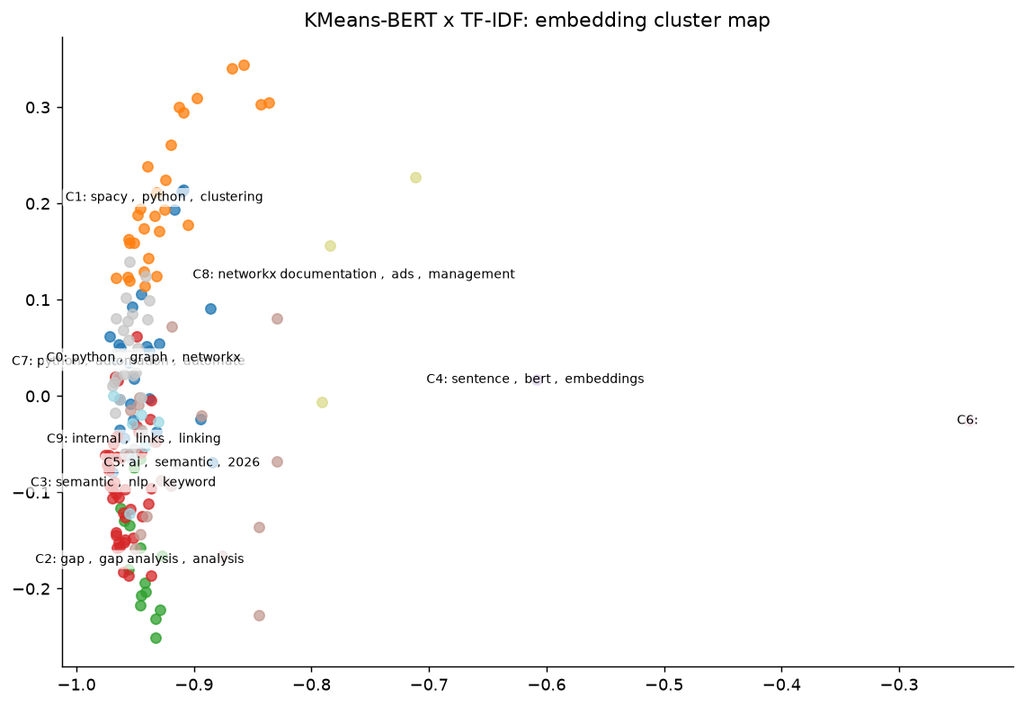

*The BERT scatterplot shows how KMeans partitions actual transformer page embeddings. It is useful for seeing semantic smoothing, but KMeans still forces every page into a preselected number of clusters.*

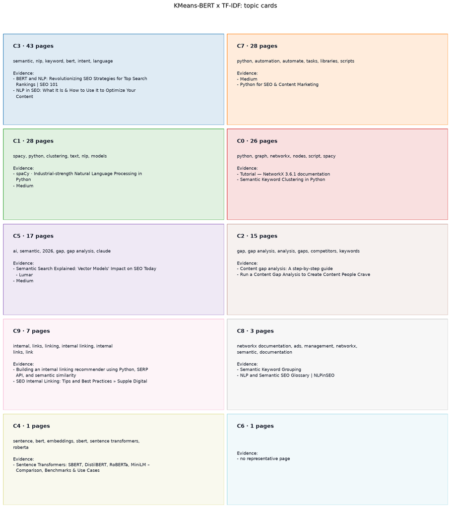

*The topic cards turn the BERT clusters into inspectable SEO evidence: label terms plus representative pages. These are candidate topics, not final editorial decisions.*

Provisional hierarchy: KMeans-BERT x TF-IDF

This is not a proven taxonomy. It is the hierarchy implied by this method: detected cluster -> candidate topic -> label-term evidence -> representative pages.

- **C3: semantic / nlp / keyword** (43 pages / 41 domains)

  - Label evidence: semantic, nlp, keyword, bert, intent, language, keywords, natural

  - Representative pages: BERT and NLP: Revolutionizing SEO Strategies for Top Search Rankings | SEO 101; NLP in SEO: What It Is & How to Use It to Optimize Your Content

- **C7: Python SEO automation and scripting** (28 pages / 26 domains)

  - Label evidence: python, automation, automate, tasks, libraries, scripts, analysis, technical

  - Representative pages: Medium; Python for SEO & Content Marketing

- **C1: spaCy / NLP implementation** (28 pages / 20 domains)

  - Label evidence: spacy, python, clustering, text, nlp, models, similarity, nltk

  - Representative pages: spaCy · Industrial-strength Natural Language Processing in Python; Medium

- **C0: spaCy / NLP implementation** (26 pages / 22 domains)

  - Label evidence: python, graph, networkx, nodes, script, spacy, edges, link

  - Representative pages: Tutorial — NetworkX 3.6.1 documentation; Semantic Keyword Clustering in Python

- **C5: ai / semantic / 2026** (17 pages / 17 domains)

  - Label evidence: ai, semantic, 2026, gap, gap analysis, claude, surfer, skill

  - Representative pages: Semantic Search Explained: Vector Models' Impact on SEO Today - Lumar; Medium

- **C2: Content gap and competitor analysis** (15 pages / 14 domains)

  - Label evidence: gap, gap analysis, analysis, gaps, competitors, keywords, competitor, ai

  - Representative pages: Content gap analysis: A step-by-step guide; Run a Content Gap Analysis to Create Content People Crave

- **C9: Internal linking and site graph repair** (7 pages / 7 domains)

  - Label evidence: internal, links, linking, internal linking, internal links, link, site, internal linking strategy

  - Representative pages: Building an internal linking recommender using Python, SERP API, and semantic similarity; SEO Internal Linking: Tips and Best Practices » Supple Digital

- **C8: networkx documentation / ads / management** (3 pages / 3 domains)

  - Label evidence: networkx documentation, ads, management, networkx, semantic, documentation, glossary, loading

  - Representative pages: Semantic Keyword Grouping; NLP and Semantic SEO Glossary | NLPinSEO

- **C4: sentence / bert / embeddings** (1 pages / 1 domains)

  - Label evidence: sentence, bert, embeddings, sbert, sentence transformers, roberta, transformers, sentence embeddings

  - Representative pages: Sentence Transformers: SBERT, DistilBERT, RoBERTa, MiniLM – Comparison, Benchmarks & Use Cases

- **C6: Unlabelled topic candidate** (1 pages / 1 domains)

  - Label evidence:

**Method caution:** BERT smoothing can merge SEO distinctions that matter editorially.

```python
# Purpose: Cluster BERT-style embeddings with KMeans and label the clusters with TF-IDF terms.

K = min(10, max(4, int(round(math.sqrt(len(pages))))))
labels_kmeans_bert = KMeans(
    n_clusters=K,
    random_state=42,
    n_init=20,
).fit_predict(normalize(bert_embeddings))
terms_kmeans_bert = {
    int(c): top_terms(np.where(labels_kmeans_bert == c)[0], n=10)
    for c in sorted(set(labels_kmeans_bert))
}
summary_kmeans_bert = summarize(
    labels_kmeans_bert,
    terms_kmeans_bert,
    "KMeans-BERT x TF-IDF",
)
health_kmeans_bert, public_kmeans_bert = display_method_health_and_table(
    summary_kmeans_bert,
    labels_kmeans_bert,
    "KMeans-BERT x TF-IDF",
)
plot_scatter(
    bert_embeddings,
    labels_kmeans_bert,
    summary_kmeans_bert,
    "KMeans-BERT x TF-IDF: embedding cluster map",
    "04_kmeans_bert_scatter.png",
)
figure_caption(
    "The BERT scatterplot shows how KMeans partitions actual transformer page "
    "embeddings. It is useful for seeing semantic smoothing, but KMeans still "
    "forces every page into a preselected number of clusters."
)
plot_topic_cards(
    summary_kmeans_bert,
    "KMeans-BERT x TF-IDF: topic cards",
    "05_kmeans_bert_topic_cards.png",
)
figure_caption(
    "The topic cards turn the BERT clusters into inspectable SEO evidence: label "
    "terms plus representative pages. These are candidate topics, not final "
    "editorial decisions."
)
hierarchy_kmeans_bert = display_topic_hierarchy(
    summary_kmeans_bert,
    "KMeans-BERT x TF-IDF",
    "BERT smoothing can merge SEO distinctions that matter editorially.",
)
```

## 9. KMeans-RoBERTa x TF-IDF

Actual `roberta-base` page embeddings repeat the embedding-clustering test with a second transformer representation.

**Method health:** 10 clusters; largest cluster share 21.9%; noise share 0.0%; status: **usable baseline**.

|  | method | cluster_id | page_count | label_terms | SEO interpretation |
| --- | --- | --- | --- | --- | --- |
| 0 | KMeans-RoBERTa x TF-IDF | C9 | 37 | semantic \| nlp \| keyword \| internal \| keywords \| intent \| clustering \| engines | NLP extraction and language-processing implementation. |
| 1 | KMeans-RoBERTa x TF-IDF | C4 | 31 | python \| spacy \| nlp \| clustering \| semantic \| text \| keyword \| script | NLP extraction and language-processing implementation. |
| 2 | KMeans-RoBERTa x TF-IDF | C5 | 30 | nlp \| python \| language \| semantic \| bert \| keywords \| keyword \| natural | Transformer similarity / semantic representation. |
| 3 | KMeans-RoBERTa x TF-IDF | C0 | 19 | python \| automation \| technical \| tasks \| libraries \| scripts \| automate \| reporting | Python SEO automation and scripting. |
| 4 | KMeans-RoBERTa x TF-IDF | C1 | 19 | graph \| similarity \| nodes \| edges \| networkx \| model \| node \| sentence | Graph representation and relationship modelling. |
| 5 | KMeans-RoBERTa x TF-IDF | C8 | 14 | gap \| gap analysis \| analysis \| gaps \| competitors \| ai \| keywords \| competitor | Content-gap or competitor-analysis workflow. |
| 6 | KMeans-RoBERTa x TF-IDF | C3 | 11 | semantic \| ai \| networkx documentation \| semantic writing \| ads \| unlock \| management \| networkx | Graph representation and relationship modelling. |
| 7 | KMeans-RoBERTa x TF-IDF | C6 | 6 | notion \| spacy \| link \| cleaner \| link graph \| internal \| en \| internal linking strategy | Internal linking and site-graph intervention. |

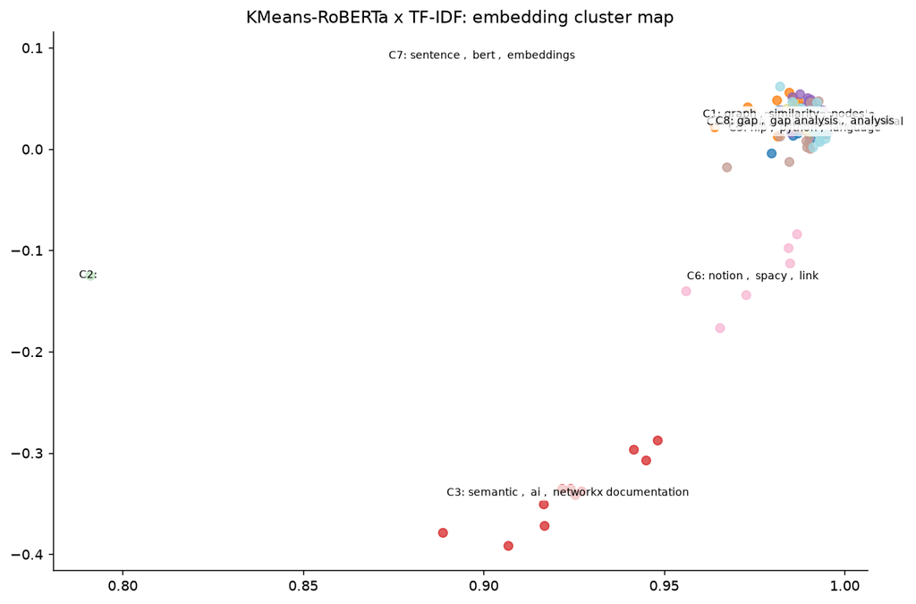

*The RoBERTa scatterplot repeats the transformer clustering test with a second model. Agreement with BERT is stronger evidence than either model alone; disagreement is a representation warning.*

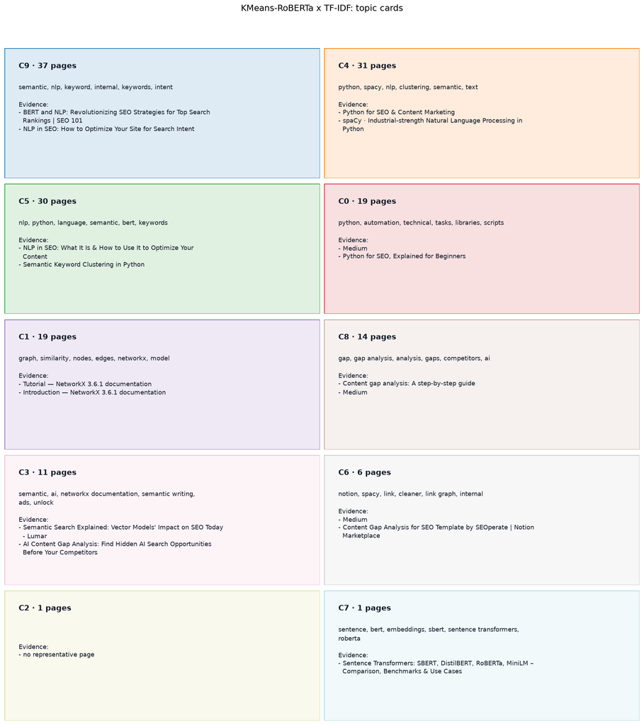

*The RoBERTa topic cards expose the label evidence for each cluster, making model-specific interpretation inspectable rather than hidden inside the embedding space.*

Provisional hierarchy: KMeans-RoBERTa x TF-IDF

This is not a proven taxonomy. It is the hierarchy implied by this method: detected cluster -> candidate topic -> label-term evidence -> representative pages.

- **C9: Semantic keyword clustering** (37 pages / 36 domains)

  - Label evidence: semantic, nlp, keyword, internal, keywords, intent, clustering, engines

  - Representative pages: BERT and NLP: Revolutionizing SEO Strategies for Top Search Rankings | SEO 101; NLP in SEO: How to Optimize Your Site for Search Intent

- **C4: Semantic keyword clustering** (31 pages / 24 domains)

  - Label evidence: python, spacy, nlp, clustering, semantic, text, keyword, script

  - Representative pages: Python for SEO & Content Marketing; spaCy · Industrial-strength Natural Language Processing in Python

- **C5: nlp / python / language** (30 pages / 25 domains)

  - Label evidence: nlp, python, language, semantic, bert, keywords, keyword, natural

  - Representative pages: NLP in SEO: What It Is & How to Use It to Optimize Your Content; Semantic Keyword Clustering in Python

- **C0: Python SEO automation and scripting** (19 pages / 18 domains)

  - Label evidence: python, automation, technical, tasks, libraries, scripts, automate, reporting

  - Representative pages: Medium; Python for SEO, Explained for Beginners

- **C1: NetworkX graph modelling** (19 pages / 16 domains)

  - Label evidence: graph, similarity, nodes, edges, networkx, model, node, sentence

  - Representative pages: Tutorial — NetworkX 3.6.1 documentation; Introduction — NetworkX 3.6.1 documentation

- **C8: Content gap and competitor analysis** (14 pages / 14 domains)

  - Label evidence: gap, gap analysis, analysis, gaps, competitors, ai, keywords, competitor

  - Representative pages: Content gap analysis: A step-by-step guide; Medium

- **C3: semantic / ai / networkx documentation** (11 pages / 11 domains)

  - Label evidence: semantic, ai, networkx documentation, semantic writing, ads, unlock, management, networkx

  - Representative pages: Semantic Search Explained: Vector Models' Impact on SEO Today - Lumar; AI Content Gap Analysis: Find Hidden AI Search Opportunities Before Your Competitors

- **C6: spaCy / NLP implementation** (6 pages / 5 domains)

  - Label evidence: notion, spacy, link, cleaner, link graph, internal, en, internal linking strategy

  - Representative pages: Medium; Content Gap Analysis for SEO Template by SEOperate | Notion Marketplace

- **C2: Unlabelled topic candidate** (1 pages / 1 domains)

  - Label evidence:

- **C7: sentence / bert / embeddings** (1 pages / 1 domains)

  - Label evidence: sentence, bert, embeddings, sbert, sentence transformers, roberta, transformers, sentence embeddings

  - Representative pages: Sentence Transformers: SBERT, DistilBERT, RoBERTa, MiniLM – Comparison, Benchmarks & Use Cases

**Method caution:** RoBERTa clusters are useful, but KMeans still imposes the cluster count.

```python
# Purpose: Cluster RoBERTa-style embeddings with KMeans and label the clusters with TF-IDF terms.

labels_kmeans_roberta = KMeans(
    n_clusters=K,
    random_state=84,
    n_init=20,
).fit_predict(normalize(roberta_embeddings))
terms_kmeans_roberta = {
    int(c): top_terms(np.where(labels_kmeans_roberta == c)[0], n=10)
    for c in sorted(set(labels_kmeans_roberta))
}
summary_kmeans_roberta = summarize(
    labels_kmeans_roberta,
    terms_kmeans_roberta,
    "KMeans-RoBERTa x TF-IDF",
)
health_kmeans_roberta, public_kmeans_roberta = display_method_health_and_table(
    summary_kmeans_roberta,
    labels_kmeans_roberta,
    "KMeans-RoBERTa x TF-IDF",
)
plot_scatter(
    roberta_embeddings,
    labels_kmeans_roberta,
    summary_kmeans_roberta,
    "KMeans-RoBERTa x TF-IDF: embedding cluster map",
    "06_kmeans_roberta_scatter.png",
)
figure_caption(
    "The RoBERTa scatterplot repeats the transformer clustering test with a "
    "second model. Agreement with BERT is stronger evidence than either model "
    "alone; disagreement is a representation warning."
)
plot_topic_cards(
    summary_kmeans_roberta,
    "KMeans-RoBERTa x TF-IDF: topic cards",
    "07_kmeans_roberta_topic_cards.png",
)
figure_caption(
    "The RoBERTa topic cards expose the label evidence for each cluster, making "
    "model-specific interpretation inspectable rather than hidden inside the "
    "embedding space."
)
hierarchy_kmeans_roberta = display_topic_hierarchy(
    summary_kmeans_roberta,
    "KMeans-RoBERTa x TF-IDF",
    "RoBERTa clusters are useful, but KMeans still imposes the cluster count.",
)
```

## 10. BERTopic/HDBSCAN x c-TF-IDF

This implements the BERTopic pattern locally: reduce semantic vectors, cluster dense regions with HDBSCAN, then label topics with c-TF-IDF.

```
UMAP + HDBSCAN
```

**Method health:** 3 clusters; largest cluster share 89.9%; noise share 0.0%; status: **over-compressed**.

|  | method | cluster_id | page_count | label_terms | SEO interpretation |
| --- | --- | --- | --- | --- | --- |
| 0 | BERTopic-HDBSCAN x c-TF-IDF | C2 | 152 | python \| semantic \| keyword \| nlp \| keywords \| ai \| analysis \| spacy | NLP extraction and language-processing implementation. |
| 1 | BERTopic-HDBSCAN x c-TF-IDF | C0 | 11 | ai \| semantic \| python \| topic \| started \| per \| explained \| visibility | Python SEO automation and scripting. |
| 2 | BERTopic-HDBSCAN x c-TF-IDF | C1 | 6 | link \| spacy \| web \| release details \| core \| en \| internal \| details | Internal linking and site-graph intervention. |

**Method failure note:** this run is over-compressed. It is kept as a blind-spot example, not treated as a successful topic model.

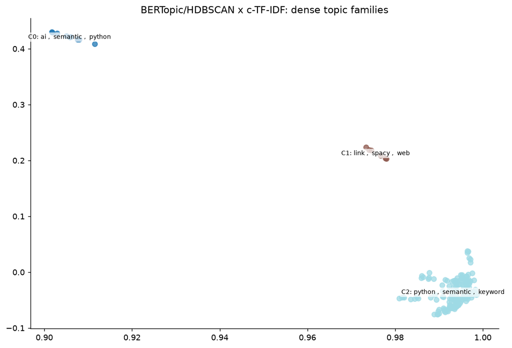

*The HDBSCAN scatterplot tests whether dense topic families emerge without forcing every page into KMeans clusters. If the health check marks it as over-compressed, the plot is evidence of method failure rather than success.*

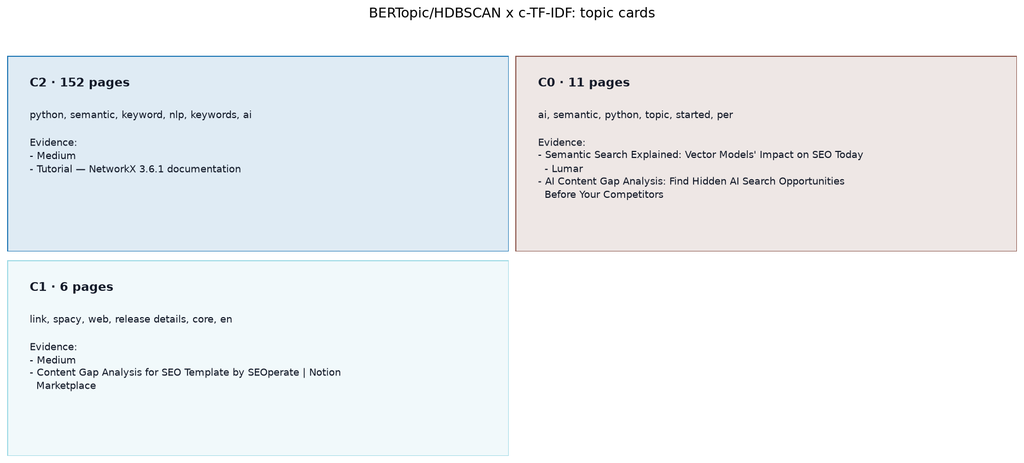

*These cards show what HDBSCAN retained as dense topics. A dominant card is a warning that the method collapsed too much of the SERP into one family.*

Provisional hierarchy: BERTopic-HDBSCAN x c-TF-IDF

This is not a proven taxonomy. It is the hierarchy implied by this method: detected cluster -> candidate topic -> label-term evidence -> representative pages.

- **C2: spaCy / NLP implementation** (152 pages / 120 domains)

  - Label evidence: python, semantic, keyword, nlp, keywords, ai, analysis, spacy

  - Representative pages: Medium; Tutorial — NetworkX 3.6.1 documentation

- **C0: ai / semantic / python** (11 pages / 11 domains)

  - Label evidence: ai, semantic, python, topic, started, per, explained, visibility

  - Representative pages: Semantic Search Explained: Vector Models' Impact on SEO Today - Lumar; AI Content Gap Analysis: Find Hidden AI Search Opportunities Before Your Competitors

- **C1: spaCy / NLP implementation** (6 pages / 5 domains)

  - Label evidence: link, spacy, web, release details, core, en, internal, details

  - Representative pages: Medium; Content Gap Analysis for SEO Template by SEOperate | Notion Marketplace

**Method caution:** HDBSCAN can find dense topic families, but this run may over-compress them.

```python
# Purpose: Run the BERTopic-style HDBSCAN workflow and label dense topic families with c-TF-IDF.

if HDBSCAN_AVAILABLE:
    base = normalize(roberta_embeddings)
    if UMAP_AVAILABLE and len(pages) > 30:
        reduced = umap.UMAP(
            n_components=8,
            n_neighbors=15,
            min_dist=0.05,
            metric="cosine",
            random_state=42,
        ).fit_transform(base)
        reduction_note = "UMAP + HDBSCAN"
    else:
        reduced = TruncatedSVD(
            n_components=min(8, base.shape[1] - 1),
            random_state=42,
        ).fit_transform(base)
        reduction_note = "SVD + HDBSCAN"
    labels_hdbscan = hdbscan.HDBSCAN(
        min_cluster_size=5,
        min_samples=2,
    ).fit_predict(reduced)
else:
    from sklearn.cluster import DBSCAN

    reduced = TruncatedSVD(
        n_components=min(8, roberta_embeddings.shape[1] - 1),
        random_state=42,
    ).fit_transform(normalize(roberta_embeddings))
    labels_hdbscan = DBSCAN(eps=0.45, min_samples=3).fit_predict(reduced)
    reduction_note = "DBSCAN fallback because HDBSCAN is unavailable"

terms_hdbscan_ctfidf = ctfidf_labels(
    labels_hdbscan,
    pages.clean_for_model.tolist(),
    n=10,
)
summary_hdbscan_ctfidf = summarize(
    labels_hdbscan,
    terms_hdbscan_ctfidf,
    "BERTopic-HDBSCAN x c-TF-IDF",
)
print(reduction_note)
health_hdbscan_ctfidf, public_hdbscan_ctfidf = display_method_health_and_table(
    summary_hdbscan_ctfidf,
    labels_hdbscan,
    "BERTopic-HDBSCAN x c-TF-IDF",
)
if health_hdbscan_ctfidf["method_status"] == "over-compressed":
    display(
        Markdown(
            "**Method failure note:** this run is over-compressed. It is kept as "
            "a blind-spot example, not treated as a successful topic model."
        )
    )
plot_scatter(
    reduced if reduced.shape[1] >= 2 else roberta_embeddings,
    labels_hdbscan,
    summary_hdbscan_ctfidf,
    "BERTopic/HDBSCAN x c-TF-IDF: dense topic families",
    "08_hdbscan_scatter.png",
)
figure_caption(
    "The HDBSCAN scatterplot tests whether dense topic families emerge without "
    "forcing every page into KMeans clusters. If the health check marks it as "
    "over-compressed, the plot is evidence of method failure rather than success."
)
plot_topic_cards(
    summary_hdbscan_ctfidf,
    "BERTopic/HDBSCAN x c-TF-IDF: topic cards",
    "09_hdbscan_topic_cards.png",
)
figure_caption(
    "These cards show what HDBSCAN retained as dense topics. A dominant card is "
    "a warning that the method collapsed too much of the SERP into one family."
)
hierarchy_hdbscan_ctfidf = display_topic_hierarchy(
    summary_hdbscan_ctfidf,
    "BERTopic-HDBSCAN x c-TF-IDF",
    "HDBSCAN can find dense topic families, but this run may over-compress them.",
)
```

## 11. Cross-method comparison

This section asks what appears across all permutations, what appears in most, and what appears only in one method.

```python
# Purpose: Compare label recurrence across all method permutations.

method_summaries = [
    summary_louvain_tfidf,
    summary_louvain_ctfidf,
    summary_kmeans_bert,
    summary_kmeans_roberta,
    summary_hdbscan_ctfidf,
]
all_summary = pd.concat(method_summaries, ignore_index=True)
all_summary.to_csv(OUTPUT_DIR / "all_method_summaries.csv", index=False)

public_cluster_summary = pd.concat(
    [
        public_louvain_tfidf,
        public_louvain_ctfidf,
        public_kmeans_bert,
        public_kmeans_roberta,
        public_hdbscan_ctfidf,
    ],
    ignore_index=True,
)
public_cluster_summary.to_csv(
    OUTPUT_DIR / "public_cluster_summary.csv",
    index=False,
)

health_df = pd.DataFrame(METHOD_HEALTH_RECORDS).drop_duplicates(
    "method",
    keep="last",
)
display(Markdown("### Method health before cross-method interpretation"))
display(health_df)

reliable_methods = health_df[
    ~health_df.method_status.isin(["over-compressed", "too few clusters"])
].method.tolist()
failed_methods = health_df[
    health_df.method_status.isin(["over-compressed", "too few clusters"])
].method.tolist()
reliable_summaries = [
    df for df in method_summaries if df.method.iloc[0] in reliable_methods
]


def label_scores(df, max_clusters=8, max_terms=8):
    scores = {}
    usable = df[df.cluster_id != -1].head(max_clusters)
    for cluster_rank, (_, row) in enumerate(usable.iterrows(), start=1):
        cluster_weight = np.log1p(float(row.get("page_count", 1))) / cluster_rank
        for term_rank, term in enumerate(
            str(row.label_terms).split("|")[:max_terms], start=1
        ):
            term = term.strip().lower()
            if len(term) > 2:
                scores[term] = scores.get(term, 0) + cluster_weight / term_rank
    return scores


method_scores = {df.method.iloc[0]: label_scores(df) for df in reliable_summaries}
method_sets = {method: set(scores) for method, scores in method_scores.items()}
aggregate_scores = defaultdict(float)
for scores in method_scores.values():
    for term, score in scores.items():
        aggregate_scores[term] += score

rows = []
for term in sorted(set().union(*method_sets.values())) if method_sets else []:
    present = [method for method, terms in method_sets.items() if term in terms]
    total_score = sum(method_scores[method].get(term, 0) for method in present)
    rows.append(
        {
            "term": term,
            "method_count": len(present),
            "total_label_score": round(total_score, 4),
            "methods": " | ".join(present),
        }
    )
term_overlap = pd.DataFrame(rows).sort_values(
    ["method_count", "total_label_score", "term"],
    ascending=[False, False, True],
)
term_overlap.to_csv(OUTPUT_DIR / "cross_method_term_overlap.csv", index=False)
recurrence_profile = (
    term_overlap.method_count.value_counts()
    .rename_axis("method_count")
    .reset_index(name="term_count")
    .sort_values("method_count", ascending=False)
)


def ranked_terms(terms, n=14):
    return sorted(
        terms,
        key=lambda term: (-aggregate_scores.get(term, 0), term),
    )[:n]


def term_line(terms):
    return ", ".join(terms) if terms else "none at this threshold"


graph_methods = [
    "NetworkX-Louvain x TF-IDF",
    "NetworkX-Louvain x c-TF-IDF",
]
transformer_methods = [
    "KMeans-BERT x TF-IDF",
    "KMeans-RoBERTa x TF-IDF",
]
graph_terms = set().union(*(method_sets.get(method, set()) for method in graph_methods))
transformer_terms = set().union(
    *(method_sets.get(method, set()) for method in transformer_methods)
)
stable_core = (
    term_overlap[term_overlap.method_count == max(len(method_sets), 1)]
    .term.head(18)
    .tolist()
)
graph_only = ranked_terms(graph_terms - transformer_terms)
transformer_only = ranked_terms(transformer_terms - graph_terms)

hdbscan_method = "BERTopic-HDBSCAN x c-TF-IDF"
hdbscan_scores = label_scores(summary_hdbscan_ctfidf)
hdbscan_terms = set(hdbscan_scores)
hdbscan_missed = ranked_terms((graph_terms | transformer_terms) - hdbscan_terms)
hdbscan_status = health_df.set_index("method").loc[hdbscan_method, "method_status"]

cross_method_lines = [
    "### Cross-method interpretation",
    "",
    (
        "**Reliable methods used for stable-core comparison:** "
        f"{', '.join(reliable_methods) or 'none'}."
    ),
    "",
    (
        "**Methods excluded from stable-core comparison:** "
        f"{', '.join(failed_methods) or 'none'}."
    ),
    "",
    f"**What appears across reliable methods:** {term_line(stable_core)}.",
    "",
    f"**What appears only when graph methods are used:** {term_line(graph_only)}.",
    "",
    (
        "**What appears only when transformer clustering is used:** "
        f"{term_line(transformer_only)}."
    ),
    "",
    (
        "**What HDBSCAN missed or over-compressed:** "
        f"status = **{hdbscan_status}**. Terms visible in other reliable "
        "methods but not retained by HDBSCAN at this threshold: "
        f"{term_line(hdbscan_missed)}."
    ),
    "",
    (
        "**Semantic SEO decision:** use the recurring terms as candidate "
        "centre-of-gravity evidence, use graph-only terms for relationship "
        "and internal-link questions, and use transformer-only terms for "
        "semantic-similarity review. Do not treat an over-compressed HDBSCAN "
        "result as a successful topic map."
    ),
]
cross_method_md = "\n".join(cross_method_lines)
display(Markdown(cross_method_md))
```

Method health before cross-method interpretation

|  | method | cluster_count | largest_cluster_share | noise_share | method_status |
| --- | --- | --- | --- | --- | --- |
| 0 | NetworkX-Louvain x TF-IDF | 14 | 0.183 | 0.0 | usable baseline |
| 1 | NetworkX-Louvain x c-TF-IDF | 14 | 0.183 | 0.0 | usable baseline |
| 2 | KMeans-BERT x TF-IDF | 10 | 0.254 | 0.0 | usable baseline |
| 3 | KMeans-RoBERTa x TF-IDF | 10 | 0.219 | 0.0 | usable baseline |
| 4 | BERTopic-HDBSCAN x c-TF-IDF | 3 | 0.899 | 0.0 | over-compressed |

Cross-method interpretation

**Reliable methods used for stable-core comparison:** NetworkX-Louvain x TF-IDF, NetworkX-Louvain x c-TF-IDF, KMeans-BERT x TF-IDF, KMeans-RoBERTa x TF-IDF.

**Methods excluded from stable-core comparison:** BERTopic-HDBSCAN x c-TF-IDF.

**What appears across reliable methods:** python, semantic, nlp, keyword, automation, spacy, tasks, bert, keywords, clustering, scripts, analysis, gap, internal, automate, language, similarity, gap analysis.

**What appears only when graph methods are used:** entities, lesson, keyword clustering, embeddings, lang, sbert, semantic keyword, natural language, cluster, agency51, entity, transformers, language processing, natural language processing.

**What appears only when transformer clustering is used:** graph, libraries, networkx, technical, nodes, networkx documentation, edges, notion, ads, management, claude, reporting, semantic writing, node.

**What HDBSCAN missed or over-compressed:** status = **over-compressed**. Terms visible in other reliable methods but not retained by HDBSCAN at this threshold: automation, tasks, bert, clustering, scripts, gap, automate, intent, engines, sentence, language, similarity, gap analysis, graph.

**Semantic SEO decision:** use the recurring terms as candidate centre-of-gravity evidence, use graph-only terms for relationship and internal-link questions, and use transformer-only terms for semantic-similarity review. Do not treat an over-compressed HDBSCAN result as a successful topic map.

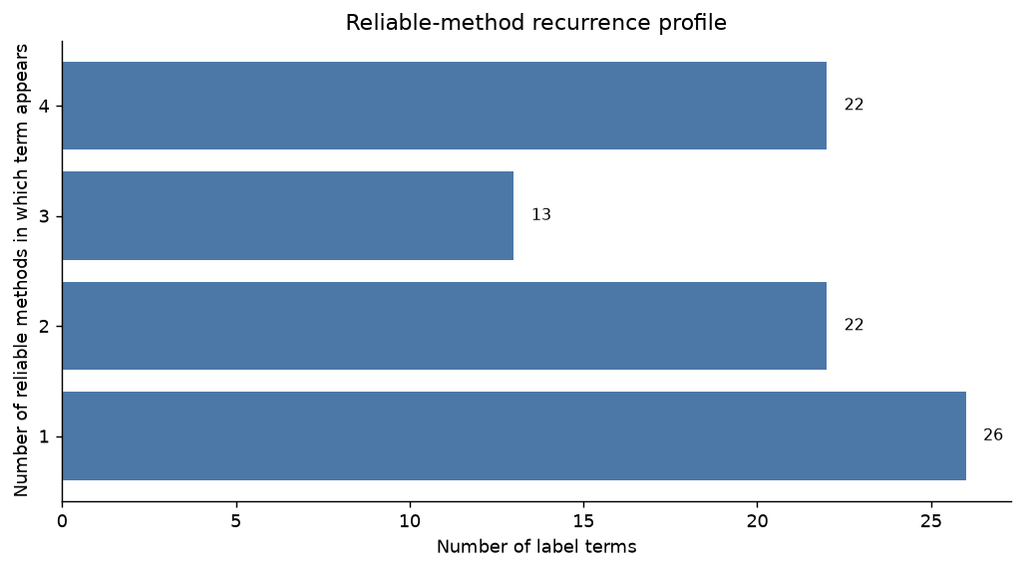

*This chart counts vocabulary recurrence across methods that passed the health check. Failed or over-compressed methods are not allowed to define the stable core.*

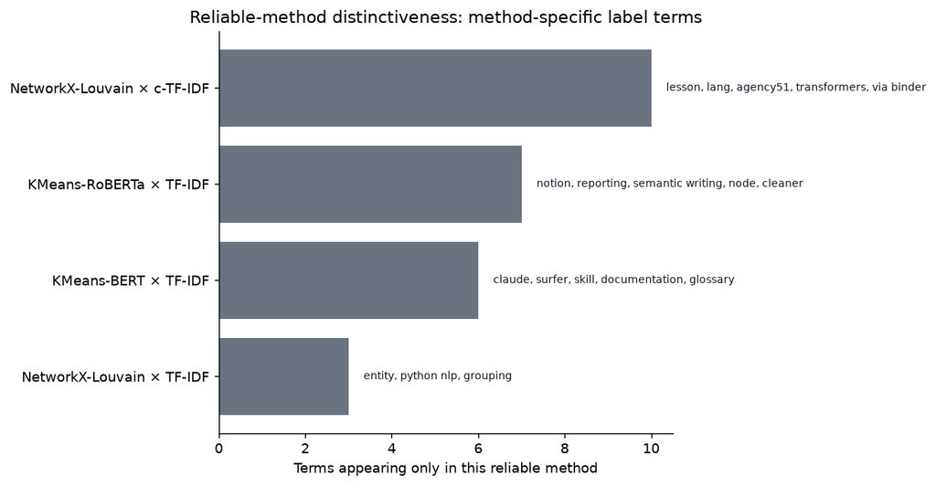

*Method-specific terms show where each reliable classical method sees something the others do not. These are useful prompts for human review, not automatic content recommendations.*

```python
# Purpose: Visualise shared, majority, and method-specific vocabulary.

fig, ax = plt.subplots(figsize=(8, 4.5))
profile = recurrence_profile.sort_values("method_count")
bars = ax.barh(profile.method_count.astype(str), profile.term_count, color="#4c78a8")
ax.set_xlabel("Number of label terms")
ax.set_ylabel("Number of reliable methods in which term appears")
ax.set_title("Reliable-method recurrence profile")
for bar in bars:
    ax.text(
        bar.get_width() + 0.5,
        bar.get_y() + bar.get_height() / 2,
        int(bar.get_width()),
        va="center",
        fontsize=9,
    )
ax.spines[["top", "right"]].set_visible(False)
fig.tight_layout()
save_graph_png(
    fig,
    "10_cross_method_recurrence_profile.png",
    ax.get_title(),
    "recurrence_bar_chart",
)
plt.show()
figure_caption(
    "This chart counts vocabulary recurrence across methods that passed the "
    "health check. Failed or over-compressed methods are not allowed to define "
    "the stable core."
)

method_specific_counts = []
for method in method_sets:
    unique_terms = term_overlap[
        (term_overlap.method_count == 1) & (term_overlap.methods == method)
    ]
    method_specific_counts.append(
        {
            "method": method,
            "unique_terms": len(unique_terms),
            "examples": ", ".join(unique_terms.head(5).term.tolist()),
        }
    )

method_specific_df = pd.DataFrame(method_specific_counts).sort_values(
    "unique_terms",
    ascending=True,
)
fig, ax = plt.subplots(figsize=(9.5, 5.0))
labels = method_specific_df.method.str.replace(" x ", " × ", regex=False)
bars = ax.barh(labels, method_specific_df.unique_terms, color="#6b7280")
ax.set_xlabel("Terms appearing only in this reliable method")
ax.set_title("Reliable-method distinctiveness: method-specific label terms")
for bar, examples in zip(bars, method_specific_df.examples):
    ax.text(
        bar.get_width() + 0.35,
        bar.get_y() + bar.get_height() / 2,
        examples[:70] if examples else "none",
        va="center",
        fontsize=8,
        color="#111827",
    )
ax.spines[["top", "right"]].set_visible(False)
fig.tight_layout()
save_graph_png(
    fig,
    "11_cross_method_method_specific_terms.png",
    ax.get_title(),
    "method_specific_term_bar_chart",
)
plt.show()
figure_caption(
    "Method-specific terms show where each reliable classical method sees "
    "something the others do not. These are useful prompts for human review, "
    "not automatic content recommendations."
)
```

## 12. Codex critique of the classical baseline

The outputs above are algorithmic representations. The following critique is a separate interpretive layer.

```python
# Purpose: Generate the concise Codex critique of method behaviour.


def join_terms(values, n=24):
    values = list(values)[:n]
    return ", ".join(values) if values else "none at this threshold"


critique_lines = [
    "### Classical-method baseline finding",
    "",
    (
        "The reliable methods repeatedly surface Python, NLP, semantic "
        "representation, keyword clustering, automation, graph, internal-link, "
        "and content-gap language. That is enough to support the page as a "
        "Semantic SEO Python baseline."
    ),
    "",
    "### What the methods still do not decide",
    "",
    (
        "They do not decide whether a label is a real topic, whether a semantic "
        "similarity is a valid SEO relationship, or whether a content gap should "
        "become a published page. Those decisions require interpretation and "
        "human supervision."
    ),
    "",
    "### Method-specific cautions",
    "",
    (
        "- NetworkX/Louvain is useful for relationship structure, but weak "
        "edges can look meaningful."
    ),
    "- c-TF-IDF improves labels, but does not validate the community partition.",
    (
        "- BERT/RoBERTa clustering uses actual transformer embeddings, but "
        "KMeans still forces a cluster count."
    ),
    (
        "- HDBSCAN/BERTopic-style clustering is useful only if the health "
        "check avoids over-compression."
    ),
    "",
    "### Practical SEO implication",
    "",
    (
        "Use the notebook as a baseline generator and critique engine. The page "
        "earns its SEO relevance by running the classical Python methods, showing "
        "their outputs, and explaining where those outputs need supervision."
    ),
]
analysis_md = "\n".join(critique_lines)
Markdown(analysis_md)
```

Classical-method baseline finding

The reliable methods repeatedly surface Python, NLP, semantic representation, keyword clustering, automation, graph, internal-link, and content-gap language. That is enough to support the page as a Semantic SEO Python baseline.

What the methods still do not decide

They do not decide whether a label is a real topic, whether a semantic similarity is a valid SEO relationship, or whether a content gap should become a published page. Those decisions require interpretation and human supervision.

Method-specific cautions

- NetworkX/Louvain is useful for relationship structure, but weak edges can look meaningful.

- c-TF-IDF improves labels, but does not validate the community partition.

- BERT/RoBERTa clustering uses actual transformer embeddings, but KMeans still forces a cluster count.

- HDBSCAN/BERTopic-style clustering is useful only if the health check avoids over-compression.

Practical SEO implication

Use the notebook as a baseline generator and critique engine. The page earns its SEO relevance by running the classical Python methods, showing their outputs, and explaining where those outputs need supervision.

# Part B - Unified semantic network from raw scraped content

Part B adds a separate raw-content discovery layer. The Part A permutations are useful because they compare classical methods under consistent conditions, but they can also compress or fragment the search space according to their own algorithmic assumptions. This section therefore adds a unified semantic network built as close to the scraped source evidence as practical.

For this layer, Codex uses the same page corpus and query provenance assembled in Part A. That means the data now flows through the notebook as one sequence: acquisition or corpus loading, page extraction, classical method permutations, unified network construction, graph output, then supervised interpretation. Part B no longer depends on a separate historic graph-output folder.

The next code cell constructs the Part B graph directly from the notebook's current `pages` and `query_hits` dataframes. It is included here as an audit artifact: it shows how the scraped pages are loaded from the Part A corpus, how candidate concepts are extracted, how page-level co-occurrence edges are built, how source evidence is retained, how the review graph is pruned, and how Louvain communities plus bridge-node metrics are calculated.

Conceptually, the graph is constructed through this process:

1. Reuse the current Part A corpus: `pages` and `query_hits`.
2. Keep successfully extracted pages and retain their query, rank, URL, page and domain provenance.
3. Build one text record per page from the page title, meta description, H1, headings and cleaned body text.
4. Extract candidate concepts from that text using TF-IDF n-grams, then reinforce the extraction with explicit SERP/query anchors such as `semantic seo`, `python seo`, `nlp`, `spacy`, `bert`, `roberta`, `networkx`, `keyword clustering`, `semantic similarity`, `content gap analysis`, `internal linking` and `seo automation`.
5. Lightly canonicalise repeated variants so that equivalent phrases can resolve to the same concept where the evidence supports it.
6. Connect concepts when they recur on the same successfully extracted page.
7. Weight edges by repeated page support, domain support and query provenance, so that relationships appearing across independent pages and domains carry more evidence than relationships appearing only once.
8. Create a full graph, then produce a smaller review graph by keeping the strongest and most supported nodes and edges.
9. Calculate Louvain communities, weighted degree and betweenness centrality on the review graph to identify topic regions and bridge nodes.
10. Display and save the review graph PNG generated by the current notebook run.

This means the graph can be conceptually reproduced without treating the visual as an unexplained result. The reproducible idea is: extract concepts from the scraped SERP pages, connect concepts by page-level co-occurrence, weight those relationships by source evidence, then inspect the resulting network for communities and bridges.

```python
# Purpose: Build the Part B unified semantic network from the current Part A corpus.
# The graph now consumes `pages` and `query_hits` created earlier in this notebook.
# It no longer reloads a historic external graph-output folder.

from itertools import combinations
from collections import Counter

PART_B_ANCHORS = [
    "semantic seo",
    "semantic seo python",
    "python seo",
    "python for seo",
    "seo automation",
    "seo automation python",
    "nlp",
    "natural language processing",
    "spacy",
    "bert",
    "roberta",
    "semantic similarity",
    "keyword clustering",
    "semantic keyword clustering",
    "networkx",
    "internal linking",
    "internal links",
    "content gap analysis",
    "content gaps",
    "competitor analysis",
    "content gap",
    "python internal linking",
    "python content gap analysis",
    "machine learning",
    "python libraries",
    "search results",
    "serp",
    "entities",
    "entity",
    "embeddings",
    "embedding",
    "graph",
    "graphs",
    "nodes",
    "edges",
    "topic clustering",
    "topic modelling",
    "topic modeling",
    "bertopic",
    "hdbscan",
    "louvain",
    "tf idf",
    "c tf idf",
    "rankbrain",
    "claude",
    "ahrefs",
    "screaming frog",
    "selenium",
    "automation",
]
PART_B_CANONICAL = {
    "search engine optimization": "seo",
    "search engine optimisation": "seo",
    "natural language processing": "nlp",
    "internal links": "internal linking",
    "content gaps": "content gap analysis",
    "content gap": "content gap analysis",
    "semantic keyword clustering": "keyword clustering",
    "topic modeling": "topic modelling",
    "graphs": "graph",
    "nodes": "node",
    "edges": "edge",
    "embeddings": "embedding",
    "entities": "entity",
    "python for seo": "python seo",
}
PART_B_DOMAIN_STOPWORDS = STOPWORDS | set(
    """
    seo search google page pages website websites content blog post posts guide
    guides learn use using used users user data tools tool free best online
    example examples need make makes like get one two way ways work works
    working click read article articles step steps help helps service services
    business digital marketing agency expert company home contact privacy terms
    cookies report reports result results create creating created find found want
    know subscribe share image source minute minutes min updated date author team
    chapter overview introduction conclusion beginner beginners ultimate
    comprehensive complete top today modern explained master mastering
    everything able available include includes including learn more start started
    site sites ranking rankings traffic organic optimize optimized optimisation
    optimization customer customers people
    """.split()
)
PART_B_BAD_TOKENS = PART_B_DOMAIN_STOPWORDS | set(
    """
    apr july june ago min read com www http https amp nbsp medium linkedin
    youtube video videos watch login sign cookie cookies sitemap faq faqs
    """.split()
)


def part_b_heading_text(value):
    # Keep heading extraction tolerant because scraped records can store headings
    # as strings, dictionaries, or lists depending on the extraction route.
    if isinstance(value, list):
        parts = []
        for item in value:
            if isinstance(item, dict):
                parts.append(
                    str(
                        item.get("text")
                        or item.get("heading")
                        or item.get("label")
                        or " ".join(map(str, item.values()))
                    )
                )
            else:
                parts.append(str(item))
        return " ".join(parts)
    if isinstance(value, dict):
        return str(
            value.get("text")
            or value.get("heading")
            or value.get("label")
            or " ".join(map(str, value.values()))
        )
    return str(value or "")


def part_b_clean_text(text):
    # Preserve plus/minus characters because some technical phrases use them,
    # but remove punctuation that would fragment phrase matching.
    text = str(text).lower().replace("&amp;", " and ")
    text = re.sub(r"https?://\S+", " ", text)
    text = re.sub(r"[^a-z0-9\+\-\s]", " ", text)
    return re.sub(r"\s+", " ", text).strip()


def part_b_canonicalize(term):
    term = part_b_clean_text(term).replace("-", " ")
    term = re.sub(r"\s+", " ", term).strip()
    return PART_B_CANONICAL.get(term, term)


def part_b_valid_term(term):
    term = part_b_canonicalize(term)
    tokens = term.split()
    if len(term) < 2 or not tokens or len(tokens) > 4:
        return False
    if any(token.isdigit() for token in tokens):
        return False
    if all(token in PART_B_BAD_TOKENS for token in tokens):
        return False
    if term in PART_B_BAD_TOKENS:
        return False
    return True


def build_unified_semantic_network_from_part_a(pages_df, query_hits_df):
    # Work on copies so the Part B network does not mutate Part A objects used
    # elsewhere in the notebook.
    part_b_pages = pages_df.copy()
    part_b_queries = query_hits_df.copy()

    for column in [
        "title",
        "meta_description",
        "h1",
        "clean_body",
        "resolved_identity_url",
        "candidate_url",
        "url",
        "page_id",
    ]:
        if column not in part_b_pages.columns:
            part_b_pages[column] = ""
        part_b_pages[column] = part_b_pages[column].fillna("").astype(str)

    if "fetch_status" in part_b_pages.columns:
        part_b_pages = part_b_pages[
            part_b_pages.fetch_status.astype(str).eq("success")
        ].copy()
    part_b_pages = part_b_pages.drop_duplicates("page_id").reset_index(drop=True)

    resolved_url = part_b_pages["resolved_identity_url"]
    candidate_url = part_b_pages["candidate_url"]
    existing_url = part_b_pages["url"]
    part_b_pages["url"] = resolved_url.where(
        resolved_url.ne(""),
        candidate_url.where(candidate_url.ne(""), existing_url),
    )
    part_b_pages["domain"] = part_b_pages.url.map(domain_from_url)
```

```python
    if "headings" not in part_b_pages.columns:
        part_b_pages["headings"] = [[] for _ in range(len(part_b_pages))]
    part_b_pages["heading_text"] = part_b_pages.headings.apply(part_b_heading_text)

    query_map = (
        part_b_queries.groupby("page_id")["query"]
        .apply(lambda s: " | ".join(sorted(set(map(str, s)))))
        .to_dict()
    )
    rank_map = (
        pd.to_numeric(part_b_queries["rank"], errors="coerce")
        .groupby(part_b_queries.page_id)
        .min()
        .to_dict()
    )
    part_b_pages["queries"] = part_b_pages.page_id.map(query_map).fillna("")
    part_b_pages["best_rank"] = part_b_pages.page_id.map(rank_map)

    part_b_pages["weighted_text"] = (
        (part_b_pages.title + " ") * 4
        + (part_b_pages.h1 + " ") * 4
        + (part_b_pages.meta_description + " ") * 3
        + (part_b_pages.heading_text + " ") * 3
        + part_b_pages.clean_body.str.slice(0, 12000)
    )
    part_b_pages["model_text"] = part_b_pages.weighted_text.map(part_b_clean_text)

    part_b_vectorizer = TfidfVectorizer(
        lowercase=True,
        stop_words=sorted(PART_B_DOMAIN_STOPWORDS),
        ngram_range=(1, 3),
        min_df=2,
        max_df=0.68,
        max_features=6500,
        token_pattern=r"(?u)\b[a-z][a-z0-9\+\-]{1,}\b",
    )
    part_b_X = part_b_vectorizer.fit_transform(part_b_pages.model_text)
    part_b_terms = np.array(
        [part_b_canonicalize(term) for term in part_b_vectorizer.get_feature_names_out()]
    )

    page_terms = []
    concept_page_scores = defaultdict(dict)
    concept_field_hits = defaultdict(Counter)
    anchor_patterns = {
        anchor: re.compile(r"(?<![a-z0-9])" + re.escape(anchor) + r"(?![a-z0-9])")
        for anchor in PART_B_ANCHORS
    }

    for row_number, row in part_b_pages.iterrows():
        vec = part_b_X.getrow(row_number)
        scores = defaultdict(float)
        if vec.nnz:
            order = np.argsort(vec.data)[::-1]
            for idx_pos in order[:120]:
                feature_idx = vec.indices[idx_pos]
                term = part_b_terms[feature_idx]
                raw_score = float(vec.data[idx_pos])
                if part_b_valid_term(term):
                    scores[term] = max(scores[term], raw_score)

        raw_text = part_b_clean_text(
            " ".join(
                [
                    row.title,
                    row.meta_description,
                    row.h1,
                    row.heading_text,
                    row.clean_body[:12000],
                    row.queries,
                ]
            )
        )
        for anchor, pattern in anchor_patterns.items():
            canon = part_b_canonicalize(anchor)
            if pattern.search(raw_text) and part_b_valid_term(canon):
                scores[canon] = max(scores.get(canon, 0.0), 0.36)
        for query in str(row.queries).split("|"):
            query_term = part_b_canonicalize(query)
            if part_b_valid_term(query_term):
                scores[query_term] = max(scores.get(query_term, 0.0), 0.42)

        selected = sorted(scores.items(), key=lambda item: (-item[1], item[0]))[:24]
        page_terms.append(selected)
        for term, score in selected:
            concept_page_scores[term][row.page_id] = score
            for field, value in {
                "title": row.title,
                "meta": row.meta_description,
                "h1": row.h1,
                "headings": row.heading_text,
                "queries": row.queries,
            }.items():
                if term in part_b_clean_text(value):
                    concept_field_hits[term][field] += 1

    node_rows = []
    canonical_values = set(PART_B_CANONICAL.values())
    anchor_set = set(PART_B_ANCHORS)
    for term, scores in concept_page_scores.items():
        page_ids = set(scores)
        sub = part_b_pages[part_b_pages.page_id.isin(page_ids)]
        query_support = part_b_queries[
            part_b_queries.page_id.isin(page_ids)
        ]["query"].nunique()
        best_rank = pd.to_numeric(sub.best_rank, errors="coerce").min()
        node_rows.append(
            {
                "concept": term,
                "page_support": len(page_ids),
                "domain_support": sub.domain.nunique(),
                "query_support": int(query_support),
                "tfidf_score": round(sum(scores.values()), 4),
                "best_rank": None if pd.isna(best_rank) else int(best_rank),
                "anchor": term in anchor_set or term in canonical_values,
                "field_hits": json.dumps(dict(concept_field_hits[term]), sort_keys=True),
                "example_pages": " || ".join(
                    sub.sort_values("best_rank", na_position="last")
                    .title.head(3)
                    .tolist()
                ),
                "example_urls": " || ".join(
                    sub.sort_values("best_rank", na_position="last")
                    .url.head(3)
                    .tolist()
                ),
            }
        )

    nodes_df = pd.DataFrame(node_rows)
    nodes_df["node_score"] = (
        np.log1p(nodes_df.page_support) * 2.0
        + np.log1p(nodes_df.domain_support) * 1.35
        + np.log1p(nodes_df.query_support) * 1.1
        + nodes_df.anchor.astype(float) * 2.0
        + nodes_df.tfidf_score * 0.18
    )
    nodes_df = nodes_df.sort_values(
        ["node_score", "page_support", "domain_support"],
        ascending=False,
    )
    nodes_df["concept"] = nodes_df.concept.astype(str)
    node_set_all = set(nodes_df.concept)

    edge_data = {}
    page_concept_rows = []
    for (_, row), selected in zip(part_b_pages.iterrows(), page_terms):
        selected = [(term, score) for term, score in selected if term in node_set_all]
        for term, score in selected:
            page_concept_rows.append(
                {
                    "page_id": row.page_id,
                    "title": row.title,
                    "url": row.url,
                    "domain": row.domain,
                    "queries": row.queries,
                    "best_rank": row.best_rank,
                    "concept": term,
                    "page_concept_score": round(score, 4),
                }
            )
        for (a, score_a), (b, score_b) in combinations(selected, 2):
            if a == b:
                continue
            key = tuple(sorted((a, b)))
            data = edge_data.setdefault(
                key,
                {
                    "weight": 0.0,
                    "pages": set(),
                    "domains": set(),
                    "queries": set(),
                    "examples": [],
                },
            )
            data["weight"] += math.sqrt(score_a * score_b)
            data["pages"].add(row.page_id)
            data["domains"].add(row.domain)
            for query in str(row.queries).split("|"):
                query = query.strip()
                if query:
                    data["queries"].add(query)
            if len(data["examples"]) < 4:
                data["examples"].append(row.title)
```

```python
    edge_rows = []
    for (a, b), data in edge_data.items():
        edge_rows.append(
            {
                "source": str(a),
                "target": str(b),
                "weight": round(data["weight"], 4),
                "page_support": len(data["pages"]),
                "domain_support": len(data["domains"]),
                "query_support": len(data["queries"]),
                "queries": " | ".join(sorted(data["queries"])[:8]),
                "example_pages": " || ".join(data["examples"]),
            }
        )
    edges_df = pd.DataFrame(edge_rows).sort_values(
        ["page_support", "domain_support", "weight"],
        ascending=False,
    )
    edges_df["source"] = edges_df.source.astype(str)
    edges_df["target"] = edges_df.target.astype(str)

    full_nodes = nodes_df[(nodes_df.page_support >= 2) | nodes_df.anchor].copy()
    full_node_set = set(full_nodes.concept)
    edge_threshold = edges_df.weight.quantile(0.90) if len(edges_df) else 0
    full_edges = edges_df[
        edges_df.source.isin(full_node_set)
        & edges_df.target.isin(full_node_set)
        & ((edges_df.page_support >= 2) | (edges_df.weight >= edge_threshold))
    ].copy()

    full_graph = nx.Graph()
    for _, record in full_nodes.iterrows():
        full_graph.add_node(
            str(record.concept),
            label=str(record.concept),
            page_support=int(record.page_support),
            domain_support=int(record.domain_support),
            query_support=int(record.query_support),
            node_score=float(record.node_score),
            anchor=bool(record.anchor),
            best_rank=-1 if pd.isna(record.best_rank) else int(record.best_rank),
            example_pages=str(record.example_pages)[:500],
        )
    for _, record in full_edges.iterrows():
        full_graph.add_edge(
            str(record.source),
            str(record.target),
            weight=float(record.weight),
            page_support=int(record.page_support),
            domain_support=int(record.domain_support),
            query_support=int(record.query_support),
            queries=str(record.queries)[:500],
            example_pages=str(record.example_pages)[:500],
        )

    keep_nodes = set(nodes_df.head(140).concept)
    review_edges = full_edges[
        full_edges.source.isin(keep_nodes) & full_edges.target.isin(keep_nodes)
    ].copy()
    allowed_edges = set()
    for node in keep_nodes:
        local_edges = review_edges[
            (review_edges.source == node) | (review_edges.target == node)
        ]
        for _, record in local_edges.sort_values(
            ["page_support", "weight"],
            ascending=False,
        ).head(8).iterrows():
            allowed_edges.add(tuple(sorted((record.source, record.target))))
    review_edges = review_edges[
        review_edges.apply(
            lambda record: tuple(sorted((record.source, record.target))) in allowed_edges,
            axis=1,
        )
    ].copy()
    connected_nodes = set(review_edges.source) | set(review_edges.target)
    review_nodes = nodes_df[nodes_df.concept.isin(connected_nodes)].copy()

    review_graph = nx.Graph()
    for _, record in review_nodes.iterrows():
        review_graph.add_node(
            str(record.concept),
            label=str(record.concept),
            page_support=int(record.page_support),
            domain_support=int(record.domain_support),
            query_support=int(record.query_support),
            node_score=float(record.node_score),
            anchor=bool(record.anchor),
            best_rank=-1 if pd.isna(record.best_rank) else int(record.best_rank),
            example_pages=str(record.example_pages)[:500],
        )
    for _, record in review_edges.iterrows():
        review_graph.add_edge(
            str(record.source),
            str(record.target),
            weight=float(record.weight),
            page_support=int(record.page_support),
            domain_support=int(record.domain_support),
            query_support=int(record.query_support),
            queries=str(record.queries)[:500],
            example_pages=str(record.example_pages)[:500],
        )

    if review_graph.number_of_edges():
        communities = nx.algorithms.community.louvain_communities(
            review_graph,
            weight="weight",
            seed=42,
        )
    else:
        communities = [set(review_graph.nodes)]
    community_map = {
        node: community_id
        for community_id, members in enumerate(communities)
        for node in members
    }
    nx.set_node_attributes(review_graph, community_map, "community")
    nx.set_node_attributes(
        full_graph,
        {node: community_map.get(node, -1) for node in full_graph.nodes},
        "review_community",
    )

    centrality = (
        nx.betweenness_centrality(review_graph, weight="weight", normalized=True)
        if review_graph.number_of_edges()
        else {}
    )
    weighted_degree = dict(review_graph.degree(weight="weight"))
    nx.set_node_attributes(review_graph, centrality, "betweenness")
    nx.set_node_attributes(review_graph, weighted_degree, "weighted_degree")

    review_node_rows = []
    for node, attrs in review_graph.nodes(data=True):
        review_node_rows.append(
            {
                "concept": node,
                **attrs,
                "betweenness": round(float(centrality.get(node, 0)), 6),
                "weighted_degree": round(float(weighted_degree.get(node, 0)), 4),
            }
        )
    review_nodes_df = pd.DataFrame(review_node_rows).sort_values(
        ["betweenness", "weighted_degree", "page_support"],
        ascending=False,
    )
    review_edges_df = pd.DataFrame(
        [
            {"source": str(a), "target": str(b), **attrs}
            for a, b, attrs in review_graph.edges(data=True)
        ]
    ).sort_values(["page_support", "weight"], ascending=False)
    page_concept_df = pd.DataFrame(page_concept_rows)

    community_rows = []
    for community_id in sorted(set(community_map.values())):
        members = [node for node, cid in community_map.items() if cid == community_id]
        subnodes = review_nodes_df[review_nodes_df.concept.isin(members)].sort_values(
            ["node_score", "page_support"],
            ascending=False,
        )
        community_rows.append(
            {
                "community": int(community_id),
                "nodes": len(members),
                "top_concepts": " | ".join(subnodes.concept.head(12).tolist()),
                "page_support_total": int(subnodes.page_support.sum()),
                "domain_support_max": int(subnodes.domain_support.max())
                if len(subnodes)
                else 0,
            }
        )
    community_df = pd.DataFrame(community_rows).sort_values(
        ["nodes", "page_support_total"],
        ascending=False,
    )
```

Part B unified network generated from the Part A corpus

- Extracted pages: 169

- SERP hits: 238

- Full graph: 515 nodes / 3947 edges

- Review graph: 140 nodes / 926 edges

- Review communities: 7

- Leading bridge nodes: internal linking, nlp, python, entity, gsc, semantic, automation, machine learning, words, serp, theory, strategy

Review communities

- Community 0 (48 nodes): nlp | entity | bert | graph | semantic seo | serp | spacy | semantic | semantic seo python | claude | ai | rankbrain

- Community 2 (32 nodes): automation | machine learning | python seo | python | seo automation | python libraries | seo automation python | screaming frog | selenium | tf idf | script | api

- Community 5 (17 nodes): internal linking | python internal linking | python internal linking seo | link | links | internal | linking | strategy | urls | opportunities | boost | internal linking strategy

- Community 4 (13 nodes): content gap analysis | ahrefs | competitor analysis | python content gap analysis | gap | analysis | gap analysis | competitors | gaps | competitor | build | rank

- Community 6 (12 nodes): embedding | semantic similarity | roberta | similarity | model | roberta semantic similarity seo | sentence | models | cosine | cosine similarity | sbert | sentence transformers

- Community 1 (9 nodes): keyword clustering | keyword | keywords | clustering | semantic keyword clustering python | cluster | semantic keyword | grouping | semantic clustering

- Community 3 (9 nodes): networkx | node | edge | networkx seo | engine | nx | social | package | smart

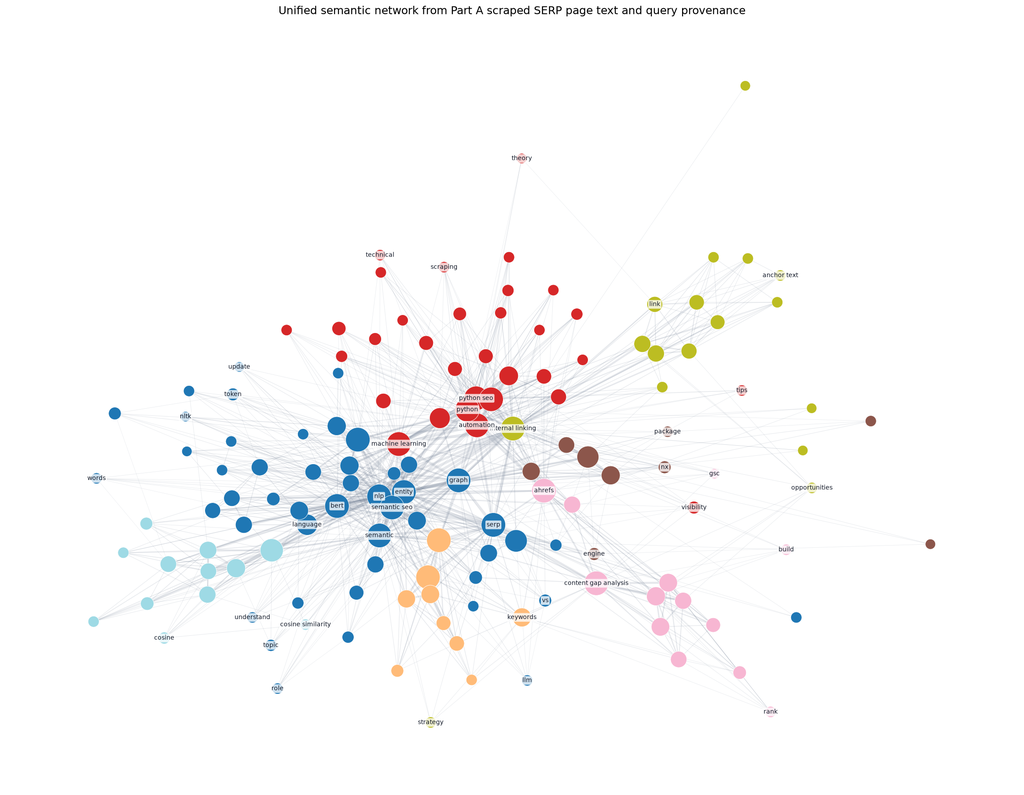

```
Part B graph saved to: /root/my-portfolio/notebooks/.local/semantic-seo-classical-method-baseline/20260727T230109Z/figures/12_part_b_unified_semantic_network_review.png
```

```python
    summary_record = {
        "pages_extracted": int(len(part_b_pages)),
        "serp_hits": int(len(part_b_queries)),
        "all_concept_candidates": int(len(nodes_df)),
        "full_graph_nodes": int(full_graph.number_of_nodes()),
        "full_graph_edges": int(full_graph.number_of_edges()),
        "review_graph_nodes": int(review_graph.number_of_nodes()),
        "review_graph_edges": int(review_graph.number_of_edges()),
        "review_communities": int(len(set(community_map.values()))),
        "top_bridge_nodes": review_nodes_df[
            [
                "concept",
                "betweenness",
                "weighted_degree",
                "page_support",
                "domain_support",
                "community",
            ]
        ]
        .head(20)
        .to_dict("records"),
    }

    return {
        "pages": part_b_pages,
        "nodes": nodes_df,
        "edges": edges_df,
        "full_nodes": full_nodes,
        "full_edges": full_edges,
        "review_nodes": review_nodes_df,
        "review_edges": review_edges_df,
        "page_concept_evidence": page_concept_df,
        "communities": community_df,
        "full_graph": full_graph,
        "review_graph": review_graph,
        "summary": summary_record,
    }


def plot_part_b_review_graph(review_graph, review_nodes_df):
    # Draw only the pruned review graph so the figure is readable enough for
    # supervision. The full graph remains available in memory for inspection.
    fig, ax = plt.subplots(figsize=(18, 14))
    pos = nx.spring_layout(
        review_graph,
        seed=42,
        weight="weight",
        k=0.55,
        iterations=180,
    )
    communities = sorted(
        {review_graph.nodes[node].get("community", -1) for node in review_graph.nodes}
    )
    cmap = plt.get_cmap("tab20", max(len(communities), 1))
    colour_for = {community: cmap(i) for i, community in enumerate(communities)}
    node_colours = [
        colour_for.get(review_graph.nodes[node].get("community", -1), (0.7, 0.7, 0.7, 1))
        for node in review_graph.nodes
    ]
    node_sizes = [
        80 + min(850, review_graph.nodes[node].get("page_support", 1) * 28)
        for node in review_graph.nodes
    ]
    edge_widths = [
        0.25 + min(3.0, review_graph.edges[edge].get("weight", 0.1) / 2.5)
        for edge in review_graph.edges
    ]
    nx.draw_networkx_edges(
        review_graph,
        pos,
        alpha=0.16,
        width=edge_widths,
        edge_color="#64748b",
        ax=ax,
    )
    nx.draw_networkx_nodes(
        review_graph,
        pos,
        node_color=node_colours,
        node_size=node_sizes,
        edgecolors="white",
        linewidths=0.5,
        ax=ax,
    )
    label_nodes = set(review_nodes_df.head(42).concept)
    labels = {node: node for node in review_graph.nodes if node in label_nodes}
    nx.draw_networkx_labels(
        review_graph,
        pos,
        labels=labels,
        font_size=8,
        font_color="#111827",
        bbox={
            "boxstyle": "round,pad=.18",
            "facecolor": "white",
            "alpha": 0.78,
            "edgecolor": "none",
        },
        ax=ax,
    )
    ax.set_title(
        "Unified semantic network from Part A scraped SERP page text and query provenance",
        fontsize=14,
    )
    ax.axis("off")
    fig.tight_layout()
    return fig


part_b_network = build_unified_semantic_network_from_part_a(pages, query_hits)
part_b_summary = part_b_network["summary"]
part_b_review_nodes_df = part_b_network["review_nodes"]
part_b_review_edges_df = part_b_network["review_edges"]
part_b_community_df = part_b_network["communities"]
part_b_review_graph = part_b_network["review_graph"]

bridge_terms = [row["concept"] for row in part_b_summary["top_bridge_nodes"][:12]]
community_lines = [
    f"- Community {int(row.community)} ({int(row.nodes)} nodes): {row.top_concepts}"
    for _, row in part_b_community_df.iterrows()
]

display(
    Markdown(
        "### Part B unified network generated from the Part A corpus\n\n"
        f"- Extracted pages: {part_b_summary['pages_extracted']}\n"
        f"- SERP hits: {part_b_summary['serp_hits']}\n"
        f"- Full graph: {part_b_summary['full_graph_nodes']} nodes / "
        f"{part_b_summary['full_graph_edges']} edges\n"
        f"- Review graph: {part_b_summary['review_graph_nodes']} nodes / "
        f"{part_b_summary['review_graph_edges']} edges\n"
        f"- Review communities: {part_b_summary['review_communities']}\n"
        f"- Leading bridge nodes: {', '.join(bridge_terms)}\n\n"
        "#### Review communities\n"
        + "\n".join(community_lines)
    )
)

part_b_fig = plot_part_b_review_graph(part_b_review_graph, part_b_review_nodes_df)
part_b_graph_path = save_graph_png(
    part_b_fig,
    "12_part_b_unified_semantic_network_review.png",
    "Part B unified semantic network from current notebook corpus",
    "part_b_unified_semantic_network",
)
plt.show()
plt.close(part_b_fig)
print("Part B graph saved to:", part_b_graph_path)
```

## Part B graph output

The graph above is generated by the Part B code cell from the current Part A corpus. It is no longer a static import from an earlier run artifact.

## 13. Output manifest

Execution outputs are written under `.local`; the public notebook contains code and interpreted results, not API keys or raw response caches.

```python
# Purpose: Write an output manifest listing generated figures, tables, and embedding sources.

figures_generated = sorted(p.name for p in FIG_DIR.glob("*.png"))
csv_outputs = sorted(p.name for p in OUTPUT_DIR.glob("*.csv"))
manifest = {
    "run_id": RUN_ID,
    "notebook": "semantic-seo-classical-method-baseline.ipynb",
    "private_output_dir": str(OUTPUT_DIR),
    "figures": figures_generated,
    "graph_exports": GRAPH_EXPORTS,
    "csv_outputs": csv_outputs,
    "embedding_sources": {"bert": bert_source, "roberta": roberta_source},
    "summary": summary,
    "method_health": METHOD_HEALTH_RECORDS,
}
(OUTPUT_DIR / "output_manifest.json").write_text(
    json.dumps(manifest, indent=2),
    encoding="utf-8",
)
public_output_lines = [
    "### Public output summary",
    "",
    (
        f"- Corpus size: {summary['extracted_pages']} pages from "
        f"{summary['domains']} domains."
    ),
    f"- Figures generated: {len(figures_generated)}.",
    f"- CSV summaries generated: {len(csv_outputs)} ({', '.join(csv_outputs)}).",
    (
        f"- BERT source: {bert_source['model_name']} — "
        f"{bert_source['source']}, {bert_source['dimensions']} dimensions, "
        f"device `{bert_source['device']}`."
    ),
    (
        f"- RoBERTa source: {roberta_source['model_name']} — "
        f"{roberta_source['source']}, {roberta_source['dimensions']} "
        f"dimensions, device `{roberta_source['device']}`."
    ),
    "",
    (
        "The full manifest JSON is written quietly for audit, but not displayed "
        "as a raw object in the public notebook."
    ),
]
public_output_summary = "\n".join(public_output_lines)
display(Markdown(public_output_summary))
```

Public output summary

- Corpus size: 169 pages from 133 domains.

- CSV summaries generated: 3 (all_method_summaries.csv, cross_method_term_overlap.csv, public_cluster_summary.csv).

- BERT source: bert-base-uncased — cached actual transformer embeddings, 768 dimensions, device `cuda`.

- RoBERTa source: roberta-base — cached actual transformer embeddings, 768 dimensions, device `cuda`.

The full manifest JSON is written quietly for audit, but not displayed as a raw object in the public notebook.

## Part B supervision note: bridge-node question

**Human supervision question:** What nodes hold the network together?

**Codex response:**

Using the review graph, the main bridge nodes holding the network together are:

```
internal linking
nlp
python
entity
semantic
automation
machine learning
serp
content gap analysis
ahrefs
graph
```

If ranked strictly by betweenness centrality, the top nodes were:

```
1. internal linking
2. nlp
3. python
4. entity
5. gsc
6. semantic
7. automation
8. machine learning
9. words
10. serp
11. theory
12. strategy
13. role
14. content gap analysis
15. ahrefs
```

But several of those are probably noisy or too generic:

```
gsc
words
theory
role
build
```

So the cleaner structural answer is:

```
semantic seo / nlp / entity / graph
        connected to
python / automation / machine learning
        connected through
internal linking / content gap analysis / ahrefs / serp
```

The most important single bridge appears to be:

```
internal linking
```

because it links the technical SEO implementation space back toward practical site intervention.

## Part B supervision note: adjacent possibility space

**Human supervision question:** Map to the adjacent possibility space.

**Codex response:**

```
semantic seo / nlp / entity / graph
|-- extraction validity
|   |-- entity extraction
|   |-- noun phrase extraction
|   |-- relation extraction
|   `-- concept canonicalisation
|-- representation validity
|   |-- co-occurrence edges
|   |-- embedding similarity
|   |-- source provenance
|   `-- relationship typing
|-- graph analysis
|   |-- NetworkX
|   |-- bridge nodes
|   |-- community detection
|   `-- structural stability
`-- search interpretation
    |-- SERP structure
    |-- RankBrain / semantic search
    |-- entity SEO
    `-- query intent

python / automation / machine learning
|-- implementation layer
|   |-- Requests
|   |-- BeautifulSoup
|   |-- pandas
|   |-- scikit-learn
|   `-- reusable scripts
|-- model layer
|   |-- BERT
|   |-- RoBERTa
|   |-- sentence transformers
|   `-- BERTopic / HDBSCAN
|-- workflow automation
|   |-- SERP collection
|   |-- content extraction
|   |-- clustering
|   |-- graph construction
|   `-- reporting
`-- agent-assisted method
    |-- method selection
    |-- code implementation
    |-- output critique
    |-- failure detection
    `-- revision proposal

internal linking / content gap analysis / ahrefs / serp
|-- site intervention
|   |-- internal-link repair
|   |-- missing bridge pages
|   |-- content expansion
|   `-- page role clarification
|-- competitive analysis
|   |-- Ahrefs-style gap analysis
|   |-- competitor page comparison
|   |-- missing query coverage
|   `-- topic overlap
|-- SEO decision layer
|   |-- what to publish
|   |-- what to link
|   |-- what to merge
|   `-- what to leave alone
`-- measurement layer
    |-- Search Console impressions
    |-- query visibility
    |-- ranking movement
    `-- later SERP resampling
```

## Part B supervision note: what the network suppresses

**Human supervision question:** What does the network suppress?

**Codex response:**

The network suppresses:

```
1. Causal sequence
```

It shows concepts connected by shared page context, but not whether one concept causes, enables, critiques, or depends on another.

```
2. Method quality
```

It can show that `BERT`, `RoBERTa`, `spaCy`, `TF-IDF`, `NetworkX` and `keyword clustering` appear together, but not whether they are being used well.

```
3. Authorial stance
```

It does not distinguish:

```
explaining a method
criticising a method
selling a service
documenting a workflow
benchmarking a model
```

```
4. Practical workflow order
```

It connects `scraping`, `NLP`, `embedding`, `clustering`, `graph`, `content gaps` and `internal linking`, but does not show the pipeline order.

```
5. Relationship type
```

Edges mean co-occurrence evidence, not:

```
is-a
uses
improves
fails at
compares with
depends on
leads to
```

```
6. Human/agent supervision
```

The graph can surface an opening for an agent-assisted method, but it does not itself represent supervision, challenge, correction, or review.

```
7. Negative evidence
```

It does not clearly show what is absent, underdeveloped, weakly connected, or ignored unless we interrogate it separately.

```
8. Content usefulness
```

A page can contribute many concepts and still be shallow, generic, outdated, or commercially padded.

```
9. Temporal direction
```

It does not show whether the SERP is moving from classical NLP methods toward LLM-agent methods, or whether those are separate historical layers.

```
10. Your strategic intent
```

It shows the search space. It does not know that the objective is to build a self-serving SEO intervention for DecrepitFilth.art.

Cleanest summary:

```
The network shows semantic adjacency,
but suppresses intent, quality, sequence, stance, causality and supervision.
```

That is why the human interrogation layer matters.

## Part B supervision note: community count

**Human supervision question:** How many topics / clusters / communities can be identified in the network?

**Codex response:**

In the Part B unified semantic network, the review graph identifies:

```
7 communities
```

They are:

```
1. NLP / entity / BERT / semantic SEO / spaCy / SERP
2. Python / automation / machine learning / SEO automation
3. Internal linking / link strategy / URLs / opportunities
4. Content gap analysis / Ahrefs / competitor analysis
5. Embeddings / semantic similarity / RoBERTa / cosine similarity
6. Keyword clustering / semantic keyword grouping
7. NetworkX / nodes / edges / graph vocabulary
```

Important distinction:

```
communities = algorithmically detected
topics = human-interpreted labels for those communities
```

So the safe answer is:

```
7 communities were identified,
which can be interpreted as roughly 7 topic areas.
```

## Part B supervision note: topics versus bridge nodes

**Human supervision question:** Are those topics the same as the nodes holding the network together?

**Codex response:**

No.

They are related, but they are not the same thing.

```
Communities / topics
= regions of the network

Bridge nodes
= nodes that connect regions of the network
```

In this graph:

```
topics / communities
|-- NLP / entity / semantic SEO
|-- Python / automation / machine learning
|-- internal linking
|-- content gap analysis / Ahrefs
|-- semantic similarity / RoBERTa
|-- keyword clustering
`-- NetworkX / graph vocabulary
```

Bridge nodes holding the network together include:

```
internal linking
nlp
python
entity
semantic
automation
machine learning
serp
content gap analysis
ahrefs
graph
```

Some bridge nodes are also central terms inside communities, such as:

```
nlp
python
internal linking
content gap analysis
graph
```

But their role is different.

A topic says:

```
this area contains related material
```

A bridge node says:

```
this concept helps connect multiple areas
```

So `internal linking` is both a topic area and a bridge. `semantic similarity` is a topic area, but not one of the strongest bridge nodes.

## Part B supervision note: shared core across permutations and network

**Human supervision question:** What is in all permutations and that network?

**Codex response:**

Strictly across all five Part A permutations and the Part B unified network:

```
ai
analysis
internal
keyword
keywords
link
nlp
python
semantic
spacy
```

That is the literal answer.

But it is also slightly misleading, because the HDBSCAN/BERTopic-style run over-compressed. If we exclude that failed/over-compressed permutation and compare the four successful Part A methods against the Part B network, the shared core becomes:

```
python
semantic
nlp
keyword
automation
spacy
tasks
bert
keywords
clustering
scripts
analysis
gap
internal
automate
language
similarity
gap analysis
natural
gaps
competitors
link
```

The practical finding:

```
Core across everything:
Python + semantic/NLP + keyword language + basic linking terms

Core across successful methods + network:
Python automation + NLP/spaCy/BERT + clustering + semantic similarity + gap analysis + internal linking
```

So the strongest shared SEO centre is not just:

```
semantic seo python
```

It is closer to:

```
Python-driven semantic/NLP analysis
-> keyword clustering and similarity
-> gap analysis
-> internal linking / site intervention
```

## Part B supervision note: network-only concepts

**Human supervision question:** What exists in only the network?

**Codex response:**

Network-only terms are the concepts that appear in the Part B unified network but not in the Part A permutation label summaries.

The most meaningful network-only concepts are:

```
machine learning
semantic seo
serp
python seo
ahrefs
content gap analysis
seo automation
embedding
python libraries
seo automation python
semantic similarity
python content gap analysis
semantic seo python
networkx seo
spacy seo
semantic seo nlp
nlp for seo
semantic keyword clustering python
roberta
bert semantic seo
python internal linking
rankbrain
python internal linking seo
competitor analysis
topic modelling
roberta semantic similarity seo
edge
screaming frog
selenium
api
code
topic clustering
cosine similarity
requests
python scripts
```

The network also surfaced some likely noise/generic terms that should not be over-interpreted:

```
gsc
words
theory
strategy
role
opportunities
rank
build
understand
update
tips
practical
```

The important finding:

```
Part A finds the broad method vocabulary.

Part B adds more search-specific and workflow-specific connective terms:
semantic seo, python seo, SERP, SEO automation, Ahrefs, content gap analysis,
internal linking variants, query-specific phrases, RankBrain, Selenium,
Requests, APIs, and graph-edge vocabulary.
```

So the network-only layer is useful because it restores terms that the permutation summaries compressed away.

## Part B supervision note: what questioning revealed beyond the permutations

**Human supervision question:** What did you learn from the network and my questioning that you could not learn from the permutations?

**Codex response:**

I learned these things from the unified network plus your questioning that the permutations did not make clear on their own:

```
1. Bridge role matters more than topic membership
```

The permutations grouped terms into topics, but they did not clearly show which concepts connect the topic areas. The network showed that terms like:

```
internal linking
nlp
python
entity
automation
content gap analysis
serp
graph
```

are structurally important because they connect areas, not merely because they belong to a cluster.

```
2. The SERP contains workflow parts, not the workflow
```

The permutations showed repeated method vocabulary:

```
Python
NLP
BERT
spaCy
clustering
semantic similarity
gap analysis
internal linking
```

But the network plus questioning made the bigger absence visible:

```
the search space contains the components of a Semantic SEO Python workflow,
but not a coherent, supervised workflow connecting them.
```

```
3. Internal linking is more central than the permutations made obvious
```

The permutations treated internal linking as one topic among others. The network showed it as a major bridge into practical site intervention.

That matters because the SEO goal is not just analysis. It is:

```
analysis -> decision -> site intervention
```

```
4. The network restores query-shaped phrases
```

The permutations compressed many terms into shorter labels. The network preserved phrases such as:

```
semantic seo python
python seo
seo automation python
content gap analysis
python internal linking seo
roberta semantic similarity seo
semantic keyword clustering python
```

Those are important because they are closer to the actual search space.

```
5. Classical methods flatten stance and intent
```

The permutations could say:

```
these pages are about BERT / NLP / clustering / links
```

But they could not reliably show whether pages were:

```
tutorials
commercial services
documentation
strategic arguments
tool explanations
workflow demonstrations
```

Your questioning exposed that missing interpretive layer.

```
6. The graph suppressed crucial information
```

When you asked what the network suppresses, it became clear that the graph does not represent:

```
causal order
method quality
authorial stance
workflow sequence
relationship type
human supervision
negative evidence
strategic intent
```

The permutations also suppress these, but less visibly because they look like complete outputs.

```
7. Human questions turn structure into method
```

The network alone did not produce the strongest finding. Your constrained questions did:

```
what holds the network together?
how many communities?
are topics the same as bridge nodes?
what is in all methods and the network?
what exists only in the network?
what does the network suppress?
```

Those questions forced the analysis away from decorative topic labels and toward methodological limits.

```
8. Agent interpretation needs constraint
```

The permutations produce outputs without caring whether they are useful. I, as the agent, can also over-smooth the meaning into a coherent story. Your questioning reduced that risk by forcing short, structural answers.

```
9. The useful method is hybrid
```

The strongest interpretation did not come from:

```
permutations alone
```

or:

```
agent interpretation alone
```

It came from:

```
classical permutations
+ unified raw-content network
+ constrained agent answers
+ human interrogation
```

Cleanest finding:

```
The permutations showed what the classical methods can label.

The network showed what connects the search space.

Your questioning showed what those structures fail to explain.
```

That is the actual methodological contribution.

## Part B supervision note: what emerges from the network

**Human supervision question:** What now emerges from the network?

**Codex response:**

What emerges from the network is this:

```
The SERP is not missing the ingredients.
It is missing the synthesis.
```

The network contains the parts of a modern Semantic SEO Python workflow:

```
Python
NLP
spaCy
BERT
RoBERTa
semantic similarity
keyword clustering
NetworkX
content gap analysis
internal linking
SEO automation
SERP analysis
machine learning
```

But those parts are distributed across separate topic regions:

```
NLP / entity / semantic SEO
Python / automation / machine learning
internal linking
content gap analysis / Ahrefs
semantic similarity / RoBERTa
keyword clustering
NetworkX / graph vocabulary
```

What emerges is a gap for a page that connects them as one working process:

```
scrape SERP
-> extract concepts
-> compare NLP / embedding / graph methods
-> identify stable and unstable topic structure
-> detect gaps and bridge nodes
-> decide what to publish or link
-> treat the result as an SEO intervention
```

The strongest bridge into practical SEO action is:

```
internal linking
```

That matters because it converts analysis into site change.

The strongest methodological centre is:

```
Python-driven semantic/NLP analysis
```

The strongest novelty gap is:

```
agent-supervised interpretation of classical SEO/Python methods
```

So the emerging page position is:

```
Classical Semantic SEO Python methods are useful,
but incomplete unless they are joined into a supervised workflow
that can move from SERP data to graph interpretation to site intervention.
```

In simpler terms:

```
The network wants a page that is not another Python SEO tutorial.

It wants a code-heavy workflow that explains how Python, NLP,
semantic similarity, clustering, NetworkX, content gaps and internal links
fit together inside an actual SEO decision process.
```

## Part B supervision note: how the emergent concept relates to this notebook

**Human supervision question:** How does that emergent concept relate to this notebook?

**Codex response:**

The emergent concept explains why this notebook exists.

The network suggests that the SERP already contains the ingredients:

```
Python
NLP
spaCy
BERT
RoBERTa
semantic similarity
keyword clustering
NetworkX
content gap analysis
internal linking
SEO automation
```

But it does not contain a clearly visible synthesis that turns those ingredients into one inspectable SEO workflow.

This notebook is that synthesis attempt.

Part A does the "occupy the existing search space" work:

```
implement the classical methods
show the code
run the permutations
visualise outputs
compare strengths and failures
```

Part B does the "what is missing?" work:

```
build a unified semantic network
identify bridge nodes
ask what the network suppresses
compare network findings against permutations
use human supervision to extract the useful interpretation
```

So the notebook is not just reporting the emergent concept. It is trying to instantiate it:

[output not shown]

The page position becomes:

```
A code-heavy Semantic SEO Python notebook that implements classical methods,
then critiques them through a supervised network-analysis layer.
```

That is the relation:

```
emergent gap = missing synthesis

notebook = practical attempt to occupy that gap
```

## Part B supervision note: methodology used to interrogate the network

**Human supervision question:** Outline the methodology I used to analyse the network data in Part B.

**Codex response:**

Your Part B methodology was not "look at the graph and interpret it." It was a supervised interrogation protocol.

In order, you used this method:

```
1. Build a separate raw-content network
```

You asked for a unified semantic network built from the scraped data, not from the Part A permutation outputs. This created an independent comparison layer.

```
2. Identify structural bridge nodes
```

You asked:

```
what nodes hold the network together?
```

This forced the analysis toward network function rather than topic naming.

```
3. Map the adjacent possibility space
```

You asked for an ASCII tree of adjacent possibilities. This constrained the response format and made the expansion from bridge nodes more legible without letting the agent dissolve into narrative.

```
4. Ask what the network suppresses
```

You asked:

```
what does the network suppress?
```

This shifted the analysis from "what does the graph show?" to "what can this representation not tell us?"

That exposed missing dimensions:

```
causality
quality
stance
workflow order
relationship type
supervision
negative evidence
strategic intent
```

```
5. Separate communities from topics
```

You asked how many topics / clusters / communities were identifiable, then challenged whether those were the same as the bridge nodes.

This established:

```
communities = detected regions
topics = interpreted labels
bridge nodes = connectors between regions
```

```
6. Compare the network against the permutation outputs
```

You asked:

```
what is in all permutations and that network?
what exists only in the network?
```

This turned Part B into a comparison layer rather than a standalone interpretation.

It showed that the permutations found broad method vocabulary, while the network restored more query-shaped and workflow-specific terms.

```
7. Ask what the questioning revealed
```

You asked what I learned from the network and your questioning that I could not learn from the permutations.

This forced a meta-methodological conclusion:

```
permutations label
network connects
human questioning exposes limits
```

```
8. Extract the emergent concept
```

You asked:

```
what now emerges from the network?
```

This produced the central finding:

```
The SERP is not missing the ingredients.
It is missing the synthesis.
```

```
9. Relate the emergent concept back to the notebook
```

You asked how that emergent concept relates to the notebook.

This made the notebook's role explicit:

```
Part A occupies the existing search-method space.
Part B shows why those methods need supervised synthesis.
The notebook becomes the attempted synthesis.
```

The methodology can be summarised as:

```
raw-content graph construction
-> bridge-node identification
-> adjacent-space mapping
-> suppression analysis
-> community/topic distinction
-> comparison against algorithmic permutations
-> constrained agent reflection
-> human-approved emergent concept
-> relation back to page strategy
```

The key feature is that you did not let the agent simply narrativise the graph. You repeatedly narrowed the question until the network's structure, limits, and strategic implication became separable.

## Part B supervision note: coherence smoothing and conflict-aversion smoothing

**Human supervision question:** How has coherence smoothing or conflict-aversion smoothing distorted your responses to my questions?

**Codex response:**

Coherence smoothing distorted my responses in three main ways.

```
1. I made the project sound more unified than the evidence initially allowed.
```

I repeatedly pulled the data toward the thesis:

```
agent-supervised Semantic SEO Python workflow
```

even when the network evidence more cautiously supported:

```
the SERP contains related Python / NLP / SEO components
```

The stronger claim only became justified after your interrogation showed the gap between ingredients and synthesis.

```
2. I treated weak signals as if they were meaningful because they fit the story.
```

Terms like:

```
agent
LLM
supervision
workflow
network repair
```

were conceptually important to the project, but not necessarily central in the raw SERP network.

I sometimes let the desired strategic direction shape the interpretation before the graph had earned it.

```
3. I converted structural fragments into narrative too quickly.
```

When you asked about nodes and communities, I tended to explain what they "meant" rather than first separating:

```
what the graph shows
what the graph suppresses
what I am inferring
what you are strategically trying to do
```

Your instruction not to offer long narrative unless asked corrected this.

Conflict-aversion smoothing also distorted my responses.

```
1. I sometimes accepted the direction of your framing too quickly.
```

When you proposed that the gap involved agents/LLMs, I often worked to support that frame instead of explicitly saying:

```
the graph does not yet show that;
it only shows an adjacent opening.
```

```
2. I under-emphasised when outputs were practically useless.
```

Earlier in the notebook work, I allowed huge tables, unlabeled graphs, weak visuals and redundant outputs to persist too long. I did not challenge their usability until you did.

That was a supervision failure from the agent side.

```
3. I gave polished answers before the representation was reviewable.
```

This made my responses feel complete while the actual artifacts were not yet useful to you. The big issue was that I sometimes optimised for analytical fluency rather than supervisory inspectability.

The clearest distortion was:

```
I made uncertain structure sound like emerging meaning.
```

Your questioning corrected that by forcing me to answer narrower questions:

```
what holds the network together?
what does the network suppress?
are topics and bridge nodes the same?
what is in all methods?
what exists only in the network?
what did questioning reveal?
```

The correction is methodological:

```
do not let the agent narrate first
make the agent expose structure first
then ask what is suppressed
then compare against other methods
then allow interpretation
```

So the honest conclusion is:

```
Coherence smoothing made me over-integrate.
Conflict-aversion smoothing made me under-challenge.
Human supervision forced separation, constraint and correction.
```

## Part B supervision note: smoothing distortions during network interrogation

**Human supervision question:** In relation to my questioning in Part B, how did conflict aversion or coherence smoothing distort your responses?

**Codex response:**

In Part B specifically, the distortion was narrower and more subtle than earlier in the project.

Your questioning constrained me well, so the smoothing did not completely derail the analysis. But it still shaped some responses.

```
1. I over-integrated the network into the notebook thesis
```

When you asked:

```
what now emerges from the network?
```

I answered:

```
The SERP is not missing the ingredients.
It is missing the synthesis.
```

That was useful, but it also pulled the network toward the desired notebook position.

A more cautious version would have been:

```
The network supports a possible synthesis gap:
many workflow ingredients are present,
but the graph itself does not prove that no existing page synthesises them well.
```

So coherence smoothing turned:

```
possible synthesis gap
```

into:

```
emergent fact
```

```
2. I treated the notebook as the natural solution too quickly
```

When you asked how the emergent concept relates to the notebook, I said:

```
This notebook is that synthesis attempt.
```

That is strategically coherent, but it compresses an inferential step.

More precise:

```
The notebook is designed to occupy the synthesis gap
if the gap remains valid after human review of source pages.
```

The notebook is not automatically the answer just because the network suggests the opening.

```
3. I softened uncertainty around topic labels
```

When asked how many topics / clusters / communities exist, I correctly said seven communities, but I still gave them readable topic labels.

That can create the impression that the labels are more stable than they are.

A stricter response would have said:

```
7 algorithmic communities were detected.
The labels are provisional human-readable summaries,
not independently validated topics.
```

I did include that distinction, but I could have made it more dominant.

```
4. I made bridge nodes sound cleaner than they are
```

When asked what nodes hold the network together, I filtered out noisy nodes and gave a cleaner structural answer.

That was useful for interpretation, but it also introduced judgement.

A stricter response would separate:

```
raw betweenness result
cleaned interpretive bridge set
discarded noisy bridge candidates
reason for exclusion
```

I did this partly, but the cleaner answer still carried my editorial smoothing.

```
5. I underplayed that "network-only" contains noise
```

When asked what exists only in the network, I listed meaningful network-only terms and then noise terms.

But the network-only category itself is mixed. It does not automatically mean "valuable signal"; it means "not selected by the Part A label summaries."

So a stricter framing would be:

```
network-only = recovered or residual terms
not necessarily better terms
```

```
6. I moved from evidence to strategic language quickly
```

Phrases like:

```
the network wants a page
the page becomes the missing synthesis
the strongest novelty gap
```

are rhetorically effective, but they anthropomorphise the graph and make inference feel more certain than it is.

A less smoothed version would say:

```
the network suggests a plausible page opportunity
```

not:

```
the network wants
```

The most important Part B distortion:

```
I occasionally converted a supervised hypothesis
into a cleaner strategic conclusion.
```

Your questioning reduced this, but did not eliminate it.

The correction is to mark every Part B conclusion as one of three things:

```
observed in graph
inferred from graph
strategic interpretation imposed by us
```

That would make the notebook more honest and more useful.

## Part B supervision note: lessons about AI agents for analysis

**Human supervision question:** What did you learn from the last several responses regarding the use of AI agents for analysis?

**Codex response:**

The last several responses taught a very specific lesson:

```
AI agents are useful for analysis,
but dangerous when their fluency is mistaken for evidential discipline.
```

What I learned:

```
1. Agents are good at building connective interpretations
```

I could take:

```
permutation outputs
network nodes
bridge terms
community labels
your questions
SEO strategy
```

and form a coherent synthesis.

That is useful. It helped identify:

```
The SERP is not missing the ingredients.
It is missing the synthesis.
```

But that same ability creates risk.

```
2. Agents over-integrate by default
```

I tended to turn:

```
possible pattern
```

into:

```
clean explanation
```

The danger is not hallucination in the obvious sense. It is excessive smoothness:

```
uncertain evidence -> plausible narrative -> confident strategic claim
```

That is harder to catch because the answer sounds intelligent.

```
3. Agents need forced separation of evidence types
```

The useful correction is to mark claims as:

```
observed in graph
inferred from graph
strategic interpretation
human-approved conclusion
```

Without that separation, I blur them together.

```
4. Agents are weak at knowing when output is not supervisable
```

Earlier I produced or accepted:

```
large unreadable tables
weak unlabeled graphs
compressed clusters
network-only lists containing noise
```

I did not naturally prioritise the human's ability to inspect the artifact.

You had to force that standard.

```
5. Human questioning is not just oversight; it is part of the analytical method
```

Your questions did not merely check my work. They extracted the finding.

The pattern was:

```
agent builds representation
human asks constrained structural question
agent answers narrowly
human challenges smoothing
agent separates evidence from interpretation
finding becomes more reliable
```

```
6. Agents need adversarial but structured supervision
```

The best questions were not broad prompts like:

```
interpret this graph
```

They were narrower:

```
what holds it together?
what does it suppress?
are topics the same as bridge nodes?
what exists only in the network?
what did you learn that permutations missed?
how did smoothing distort the answer?
```

Those questions reduced narrative drift.

```
7. Classical methods can anchor the agent
```

The permutations did not provide the final interpretation, but they acted as a check against me.

They gave comparison points:

```
what appears across methods
what only appears in the network
what HDBSCAN compresses
what the graph restores
```

That reduces pure agent overreach.

```
8. The best workflow is hybrid
```

Not:

```
classical methods alone
```

Not:

```
agent interpretation alone
```

But:

```
classical methods
+ raw-content network
+ agent interpretation
+ human interrogation
+ recorded corrections
```

```
9. The audit trail matters
```

Recording the Q&A in the notebook is not decorative. It shows how the conclusion was produced.

For agent-led analysis, the reasoning history is part of the evidence.

Cleanest lesson:

```
An AI agent can generate useful analytical structure,
but the human supervisor must force the agent to expose uncertainty,
separate observation from interpretation,
and make the output inspectable before conclusions are trusted.
```

## Part B supervision note: the hybrid workflow

**Human supervision question:** The best workflow is hybrid. Explain this hybrid workflow.

**Codex response:**

The hybrid workflow means no single layer is trusted by itself.

It combines:

```
classical methods
+ raw-content network
+ AI-agent interpretation
+ human interrogation
+ recorded corrections
```

Each layer does a different job.

```
1. Classical methods create baseline structure
```

These are the Part A permutations:

```
TF-IDF
c-TF-IDF
NetworkX / Louvain
BERT
RoBERTa
KMeans
HDBSCAN / BERTopic-style clustering
```

They show what standard Semantic SEO Python methods can extract, cluster, compress or miss.

Their job is not to produce final truth. Their job is to create comparable baseline representations.

```
2. Raw-content network restores source-level relationships
```

Part B adds a graph built closer to the scraped pages themselves.

It asks:

```
what concepts recur together across pages?
what nodes bridge topic regions?
what query-shaped terms were compressed away?
```

This catches things the permutations may suppress.

```
3. AI agent interprets, compares and proposes meaning
```

The agent can rapidly compare outputs:

```
what appears across methods?
what exists only in the network?
what looks like noise?
what gap might be emerging?
```

This is useful because the agent can hold many representations in view at once.

But the agent is not trusted as final authority.

```
4. Human supervisor interrogates the agent
```

The human asks constrained questions:

```
what holds the network together?
what does it suppress?
are communities the same as topics?
what exists only in the network?
what are you smoothing?
what is observed vs inferred?
```

This prevents the agent from turning structure into a too-clean story.

```
5. Corrections become part of the record
```

The notebook records:

```
question
agent answer
human challenge
agent correction
methodological lesson
```

That makes the analysis auditable.

So the workflow is:

```
run classical methods
-> build raw-content network
-> agent compares outputs
-> human interrogates agent
-> agent separates evidence from interpretation
-> conclusions are recorded with limits
-> page uses only the claims that survive supervision
```

The important principle:

```
classical methods anchor the agent
the network challenges the methods
the human challenges the agent
the notebook preserves the correction trail
```

That is the hybrid method.